# Project_Bank_Churn_Prediction_NN

## **Project Description**

#### **Background and Context**

Businesses like banks that provide service have to worry about the problem of 'Churn' i.e. customers leaving and joining another service provider. It is important to understand which aspects of the service influence a customer's decision in this regard. Management can concentrate efforts on the improvement of service, keeping in mind these priorities.

#### **Objective**

Given a Bank customer, build a neural network-based classifier that can determine whether they will leave or not in the next 6 months.

#### **Data Description**

The case study is from an open-source dataset from Kaggle. The dataset contains 10,000 sample points with 14 distinct features such as CustomerId, CreditScore, Geography, Gender, Age, Tenure, Balance, etc.

#### **Data Dictionary**

- RowNumber: Row number
- CustomerId: Unique identification key for different customers
- Surname: Surname of the customer
- Credit Score: A credit score is a measure of an individual's ability to pay back the borrowed amount. It is the numerical representation of their creditworthiness. A credit score is a 3-digit number that falls in the range of 300-900, 900 being the highest.
- Geography: The country to which the customer belongs
- Gender: The gender of the customer
- Age: Age of the customer
- Tenure: The period of time a customer has been associated with the bank
- Balance: The account balance (the amount of money deposited in the bank account) of the customer.
- NumOfProducts: How many accounts, bank account affiliated products the person has.
- HasCrCard: Does the customer have a credit card through the bank?
- IsActiveMember: Subjective, but for the concept
- EstimatedSalary: Estimated salary of the customer
- Exited: Did they leave the bank after all?

##### **Importing Libraries**

```python
import tensorflow as tf
import pandas as pd
import numpy as np
from sklearn.model_selection import train_test_split
from sklearn import preprocessing
from sklearn.preprocessing import MinMaxScaler
from tensorflow.keras.models import Sequential
from tensorflow.keras.layers import Dense, Dropout
from sklearn.metrics import accuracy_score, confusion_matrix, precision_score, recall_score, f1_score, precision_recall_curve, auc
import matplotlib.pyplot as plt
%matplotlib inline
from tensorflow.keras import optimizers
from sklearn.decomposition import PCA
import seaborn as sns
import keras
from keras import backend as K
from keras.models import Sequential
from keras.layers import Dense, Dropout
from keras.optimizers import Adam
from sklearn.metrics import roc_curve
from sklearn.metrics import roc_auc_score
from sklearn.metrics import classification_report
from sklearn.utils import class_weight
from imblearn.over_sampling import SMOTE
from imblearn.under_sampling import RandomUnderSampler
from sklearn.ensemble import RandomForestClassifier

import warnings
warnings.filterwarnings("ignore")
```

```python
#checking tensorflow version
print(tf.__version__)
```

```
2.5.0
```

##### **Reading Dataset and Feature Elimination**

```python
#mouting the drive
from google.colab import drive
drive.mount('/content/drive/')
```

```python
#Set the path of the dataset
ds_path = '/content/drive/My Drive/'
ds_path = ds_path + 'bank.csv'
```

```python
#Reading the dataset
dataCC = pd.read_csv(ds_path)
```

```python
#Keeping a copy of the original dataset for later
data = dataCC.copy()
```

##### **Overview of the dataset**

##### **View first 10 and last 10 rows of the dataset**

```python
#First 10 records
dataCC.head(10)
```

|  | RowNumber | CustomerId | Surname | CreditScore | Geography | Gender | Age | Tenure | Balance | NumOfProducts | HasCrCard | IsActiveMember | EstimatedSalary | Exited |
| --- | --- | --- | --- | --- | --- | --- | --- | --- | --- | --- | --- | --- | --- | --- |
| 0 | 1 | 15634602 | Hargrave | 619 | France | Female | 42 | 2 | 0.00 | 1 | 1 | 1 | 101348.88 | 1 |
| 1 | 2 | 15647311 | Hill | 608 | Spain | Female | 41 | 1 | 83807.86 | 1 | 0 | 1 | 112542.58 | 0 |
| 2 | 3 | 15619304 | Onio | 502 | France | Female | 42 | 8 | 159660.80 | 3 | 1 | 0 | 113931.57 | 1 |
| 3 | 4 | 15701354 | Boni | 699 | France | Female | 39 | 1 | 0.00 | 2 | 0 | 0 | 93826.63 | 0 |
| 4 | 5 | 15737888 | Mitchell | 850 | Spain | Female | 43 | 2 | 125510.82 | 1 | 1 | 1 | 79084.10 | 0 |
| 5 | 6 | 15574012 | Chu | 645 | Spain | Male | 44 | 8 | 113755.78 | 2 | 1 | 0 | 149756.71 | 1 |
| 6 | 7 | 15592531 | Bartlett | 822 | France | Male | 50 | 7 | 0.00 | 2 | 1 | 1 | 10062.80 | 0 |
| 7 | 8 | 15656148 | Obinna | 376 | Germany | Female | 29 | 4 | 115046.74 | 4 | 1 | 0 | 119346.88 | 1 |
| 8 | 9 | 15792365 | He | 501 | France | Male | 44 | 4 | 142051.07 | 2 | 0 | 1 | 74940.50 | 0 |
| 9 | 10 | 15592389 | H? | 684 | France | Male | 27 | 2 | 134603.88 | 1 | 1 | 1 | 71725.73 | 0 |

```python
#Last 10 records
dataCC.tail(10)
```

|  | RowNumber | CustomerId | Surname | CreditScore | Geography | Gender | Age | Tenure | Balance | NumOfProducts | HasCrCard | IsActiveMember | EstimatedSalary | Exited |
| --- | --- | --- | --- | --- | --- | --- | --- | --- | --- | --- | --- | --- | --- | --- |
| 9990 | 9991 | 15798964 | Nkemakonam | 714 | Germany | Male | 33 | 3 | 35016.60 | 1 | 1 | 0 | 53667.08 | 0 |
| 9991 | 9992 | 15769959 | Ajuluchukwu | 597 | France | Female | 53 | 4 | 88381.21 | 1 | 1 | 0 | 69384.71 | 1 |
| 9992 | 9993 | 15657105 | Chukwualuka | 726 | Spain | Male | 36 | 2 | 0.00 | 1 | 1 | 0 | 195192.40 | 0 |
| 9993 | 9994 | 15569266 | Rahman | 644 | France | Male | 28 | 7 | 155060.41 | 1 | 1 | 0 | 29179.52 | 0 |
| 9994 | 9995 | 15719294 | Wood | 800 | France | Female | 29 | 2 | 0.00 | 2 | 0 | 0 | 167773.55 | 0 |
| 9995 | 9996 | 15606229 | Obijiaku | 771 | France | Male | 39 | 5 | 0.00 | 2 | 1 | 0 | 96270.64 | 0 |
| 9996 | 9997 | 15569892 | Johnstone | 516 | France | Male | 35 | 10 | 57369.61 | 1 | 1 | 1 | 101699.77 | 0 |
| 9997 | 9998 | 15584532 | Liu | 709 | France | Female | 36 | 7 | 0.00 | 1 | 0 | 1 | 42085.58 | 1 |
| 9998 | 9999 | 15682355 | Sabbatini | 772 | Germany | Male | 42 | 3 | 75075.31 | 2 | 1 | 0 | 92888.52 | 1 |
| 9999 | 10000 | 15628319 | Walker | 792 | France | Female | 28 | 4 | 130142.79 | 1 | 1 | 0 | 38190.78 | 0 |

- From the first and last 10 rows, looks like different columns have different scales (some are in 1000s, some in 100s and some in 1s)

##### **Checking Shape**

```python
#Checking shape of the dataset
dataCC.shape
```

```
(10000, 14)
```

- The dataset has 10,000 rows and 14 columns

##### **Checking data types and number of non-null values for each column**

```python
#Checking info to see data types and nulls (if there are any)
dataCC.info()
```

```
<class 'pandas.core.frame.DataFrame'>
RangeIndex: 10000 entries, 0 to 9999
Data columns (total 14 columns):
 #   Column           Non-Null Count  Dtype
---  ------           --------------  -----
 0   RowNumber        10000 non-null  int64
 1   CustomerId       10000 non-null  int64
 2   Surname          10000 non-null  object
 3   CreditScore      10000 non-null  int64
 4   Geography        10000 non-null  object
 5   Gender           10000 non-null  object
 6   Age              10000 non-null  int64
 7   Tenure           10000 non-null  int64
 8   Balance          10000 non-null  float64
 9   NumOfProducts    10000 non-null  int64
 10  HasCrCard        10000 non-null  int64
 11  IsActiveMember   10000 non-null  int64
 12  EstimatedSalary  10000 non-null  float64
 13  Exited           10000 non-null  int64
dtypes: float64(2), int64(9), object(3)
memory usage: 1.1+ MB
```

- We can see that there are 10,000 rows and 14 attributes including the output attribute (Exited) in this dataset
- There are no null values in any of the column, since the number of non-null values in each column equals the total number of rows (10,000)
- Surname, Geography and Gender are object types
- All other columns are numeric types (int or float)

##### **NULL (missing value) check**

```python
#Null check using isnull()
dataCC.isnull().sum()
```

```
RowNumber          0
CustomerId         0
Surname            0
CreditScore        0
Geography          0
Gender             0
Age                0
Tenure             0
Balance            0
NumOfProducts      0
HasCrCard          0
IsActiveMember     0
EstimatedSalary    0
Exited             0
dtype: int64
```

- NULL values are not present in the dataset

##### **Number of unique values in each column**

```python
#Number of unique values in each column
dataCC.nunique()
```

```
RowNumber          10000
CustomerId         10000
Surname             2932
CreditScore          460
Geography              3
Gender                 2
Age                   70
Tenure                11
Balance             6382
NumOfProducts          4
HasCrCard              2
IsActiveMember         2
EstimatedSalary     9999
Exited                 2
dtype: int64
```

- Rownumber is an ID column with unique value for each row and won't add value to the model, it can be dropped
- CustomerId is also an ID column with unique value for each row and won't add value to the model, it can be dropped
- Geography, Gender, Tenure, NumOfProducts, HasCrCard and IsActiveMember have only a handful of values and can be thought of as categorical columns
- Exited is the target variable and has two classes
- CreditScore, Age, Balance and EstimatedSalary seem to be continuous variables
- Surname is object type and has 2932 unique values, but this is just name and not going to add value to the model, it can be dropped

##### **Dropping ID columns**

```python
#Dropping Rownumber
dataCC.drop('RowNumber',axis=1,inplace=True)
```

```python
#Dropping CustomerId
dataCC.drop('CustomerId',axis=1,inplace=True)
```

```python
#Dropping Surname
dataCC.drop('Surname',axis=1,inplace=True)
```

```python
#Checking shape again to make sure the columns are dropped
dataCC.shape
```

```
(10000, 11)
```

##### **Summary of the dataset**

```python
#Statistical summary of the dataset (only numeric columns)
dataCC.describe().T
```

|  | count | mean | std | min | 25% | 50% | 75% | max |
| --- | --- | --- | --- | --- | --- | --- | --- | --- |
| CreditScore | 10000.0 | 650.528800 | 96.653299 | 350.00 | 584.00 | 652.000 | 718.0000 | 850.00 |
| Age | 10000.0 | 38.921800 | 10.487806 | 18.00 | 32.00 | 37.000 | 44.0000 | 92.00 |
| Tenure | 10000.0 | 5.012800 | 2.892174 | 0.00 | 3.00 | 5.000 | 7.0000 | 10.00 |
| Balance | 10000.0 | 76485.889288 | 62397.405202 | 0.00 | 0.00 | 97198.540 | 127644.2400 | 250898.09 |
| NumOfProducts | 10000.0 | 1.530200 | 0.581654 | 1.00 | 1.00 | 1.000 | 2.0000 | 4.00 |
| HasCrCard | 10000.0 | 0.705500 | 0.455840 | 0.00 | 0.00 | 1.000 | 1.0000 | 1.00 |
| IsActiveMember | 10000.0 | 0.515100 | 0.499797 | 0.00 | 0.00 | 1.000 | 1.0000 | 1.00 |
| EstimatedSalary | 10000.0 | 100090.239881 | 57510.492818 | 11.58 | 51002.11 | 100193.915 | 149388.2475 | 199992.48 |
| Exited | 10000.0 | 0.203700 | 0.402769 | 0.00 | 0.00 | 0.000 | 0.0000 | 1.00 |

- CreditScore ranges from 350 to 850, mean and median are close, fairly normal distribution
- Age ranges from 18 to 92, mean and median are close, but there is a big difference between 75% and max values, which indicates the data could be skewed or possible outliers
- Tenure ranges from 0 to 10, mean and median are close, fairly normal distribution
- Balance ranges from 0 to 250898.09, mean is less compared to median, indicates left skewed data distribution
- NumberOfProducts ranges from 1 to 4, 75% of data points are for number of products 1 and 2
- HasCrCard is a binary variable, shows customer has credit card or not
- IsActiveMember is a binary variable, shows active customer or not
- EstimatedSalary ranges from 11.58 to 199992.48 (really large range), mean and median are close, 25% customers have salary upto 51K, 50% at almost 100K, 75% almost at 150K and max around 200K, so kind of normally distributed
- Exited is our target variable, is binary, shows customer left bank services or not

```python
#Summary of non-numeric columns
dataCC.describe(include=[object]).T
```

|  | count | unique | top | freq |
| --- | --- | --- | --- | --- |
| Geography | 10000 | 3 | France | 5014 |
| Gender | 10000 | 2 | Male | 5457 |

- Both object type columns look like category, from number of unique values
- No null values in these object type columns
- Geography has 3 unique values and record count is more for 'France'
- Gender has 2 unique values and record count is more for 'Male'

##### **Checking for duplicate records in the dataset**

```python
#Checking for duplicate records in the dataset
dataCC.duplicated().sum()
```

```
0
```

- No duplicates found in the dataset

##### **Checking the count of each unique category in categorical variables**

```python
cat_cols = ['Geography', 'Gender', 'Tenure', 'NumOfProducts', 'HasCrCard', 'IsActiveMember', 'Exited']

for col in cat_cols:
    print(dataCC[col].value_counts())
    print('-'*50)
```

```
France     5014
Germany    2509
Spain      2477
Name: Geography, dtype: int64
--------------------------------------------------
Male      5457
Female    4543
Name: Gender, dtype: int64
--------------------------------------------------
2     1048
1     1035
7     1028
8     1025
5     1012
3     1009
4      989
9      984
6      967
10     490
0      413
Name: Tenure, dtype: int64
--------------------------------------------------
1    5084
2    4590
3     266
4      60
Name: NumOfProducts, dtype: int64
--------------------------------------------------
1    7055
0    2945
Name: HasCrCard, dtype: int64
--------------------------------------------------
1    5151
0    4849
Name: IsActiveMember, dtype: int64
--------------------------------------------------
0    7963
1    2037
Name: Exited, dtype: int64
--------------------------------------------------
```

- Unique values for Geography are France,Germany and Spain. France has more data points in this dataset.
- Unique values for Gender are Male and Female. Male has more data points than Female.
- Tenure has 11 unique values, 0 to 10. **Tenure 0 has 413 data points, data description does not say if this months or years, since there are 413 data points, I assume we need to keep these data points with tenure = 0 and it could be tenure in years**.
- NumOfProducts has unique values 1,2,3 and 4. 1 has more data points than others.
- HasCrCard is a binary variable, number of customers with credit card is more in this dataset.
- IsActiveMember is a binary variable, number of active customers is slightly more than inactive count.
- Exited is the target variable, binary variable, number of customers who left bank services is less comapred number of customers who continue to use bank services.

```python
#Converting object types to category
for col in dataCC.columns:
    if dataCC[col].dtype == 'object':
        dataCC[col] = dataCC[col].astype('category')
```

```python
dataCC.info()
```

```
<class 'pandas.core.frame.DataFrame'>
RangeIndex: 10000 entries, 0 to 9999
Data columns (total 11 columns):
 #   Column           Non-Null Count  Dtype
---  ------           --------------  -----
 0   CreditScore      10000 non-null  int64
 1   Geography        10000 non-null  category
 2   Gender           10000 non-null  category
 3   Age              10000 non-null  int64
 4   Tenure           10000 non-null  int64
 5   Balance          10000 non-null  float64
 6   NumOfProducts    10000 non-null  int64
 7   HasCrCard        10000 non-null  int64
 8   IsActiveMember   10000 non-null  int64
 9   EstimatedSalary  10000 non-null  float64
 10  Exited           10000 non-null  int64
dtypes: category(2), float64(2), int64(7)
memory usage: 723.0 KB
```

- This reduces memory usage, we will be doing one-hot encoding on these categorical variables before model building

##### **Checking data inbalance in the dataset for the 2 output classes**

```python
#checking the percentage of each class in the dataset
(dataCC.Exited.value_counts())/(dataCC.Exited.count())
```

```
0    0.7963
1    0.2037
Name: Exited, dtype: float64
```

- 79.63% customers in this dataset continue to use bank services whereas 20.37% leaves bank services. And we are going to predict the 2nd class, customers leaving bank services.

##### **EDA - univariate analysis**

##### **Univariate analysis for continuous variables using boxplot and histogram**

```python
# Function to create boxplot and histogram for any input numerical variable
# This function takes the numerical column as the input and returns the boxplots
# and histograms for the variable.

def histogram_boxplot(feature, figsize=(15,10), bins = None):
    """ Boxplot and histogram combined
    feature: 1-d feature array
    figsize: size of fig (default (9,8))
    bins: number of bins (default None / auto)
    """
    f2, (ax_box2, ax_hist2) = plt.subplots(nrows = 2, # Number of rows of the subplot grid= 2
                                           sharex = True, # x-axis will be shared among all subplots
                                           gridspec_kw = {"height_ratios": (.25, .75)},
                                           figsize = figsize
                                           ) # creating the 2 subplots
    sns.boxplot(feature, ax=ax_box2, showmeans=True, color='violet') # boxplot will be created and a star will indicate the mean value of the column
    sns.histplot(feature, kde=F, ax=ax_hist2, bins=bins,palette="winter") if bins else sns.histplot(feature, kde=False, ax=ax_hist2) # For histogram
    ax_hist2.axvline(np.mean(feature), color='green', linestyle='--') # Add mean to the histogram
    ax_hist2.axvline(np.median(feature), color='black', linestyle='-') # Add median to the histogram
```

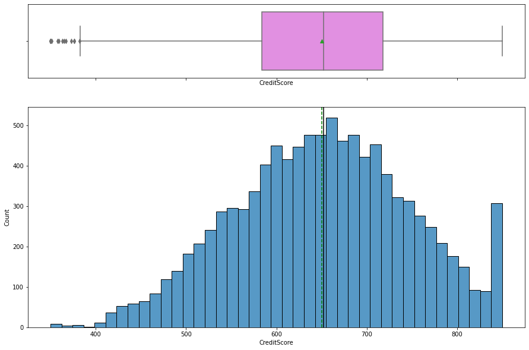

```python
#CreditScore
histogram_boxplot(dataCC['CreditScore'])
```

- Mean and Median are very close to each other
- Fairly normal distribution of data
- There are couple of outliers towards the left end

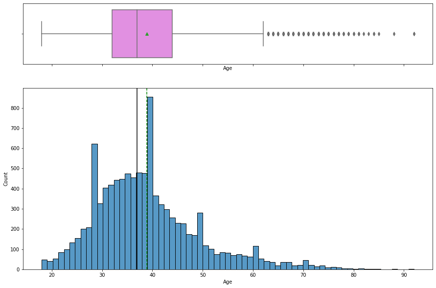

```python
#Age
histogram_boxplot(dataCC['Age'])
```

- Mean and Median are close
- Most of the data points are below 50
- There are outliers towards the right end of the data

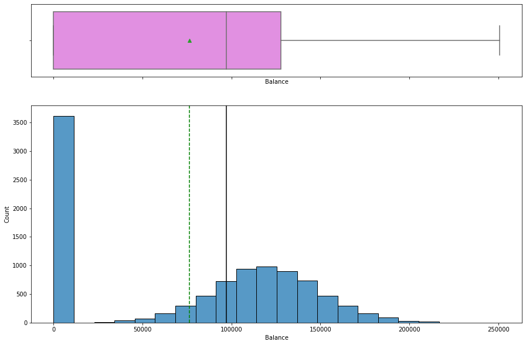

```python
#Balance
histogram_boxplot(dataCC['Balance'])
```

- Mean is less compared to median, left skewed distribution
- There is a wide range of data points with peak towards the least end

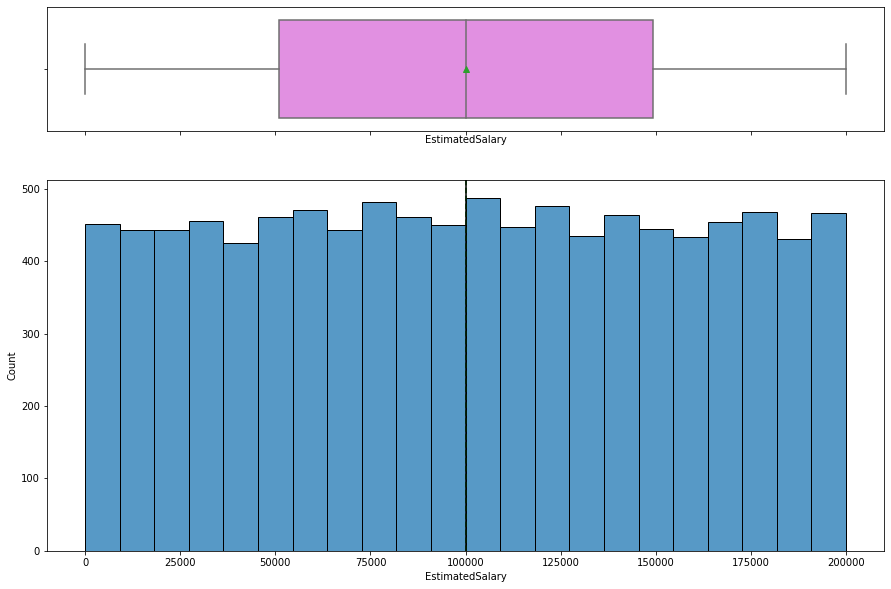

```python
#EstimatedSalary
histogram_boxplot(dataCC['EstimatedSalary'])
```

- Mean and Median are very close
- No outliers are seen and almost fairly distributed

##### **Checking outliers**

```python
#Finding percentage of outliers, in each column of the data, using IQR
num_cols = ['CreditScore','Age','Balance','EstimatedSalary']
Q1 = dataCC[num_cols].quantile(0.25) #25th percentile
Q3 = dataCC[num_cols].quantile(0.75) #75th percentile

#Inter Quantile Range (75th perentile - 25th percentile)
IQR = Q3 - Q1

#Finding lower and upper bounds based on IQR. All values outside these bounds are considered outliers
lower=Q1-1.5*IQR
upper=Q3+1.5*IQR
```

```python
#Outliers towards left end
((dataCC[num_cols] < lower)).sum()/len(dataCC[num_cols])*100
```

```
CreditScore        0.15
Age                0.00
Balance            0.00
EstimatedSalary    0.00
dtype: float64
```

```python
#Outliers towards right end
((dataCC[num_cols] > upper)).sum()/len(dataCC[num_cols])*100
```

```
CreditScore        0.00
Age                3.59
Balance            0.00
EstimatedSalary    0.00
dtype: float64
```

- CreditScore and Age have outliers, we have already seen this in boxplot.
- Age has outliers towards right end
- CreditScore has ouliers towards left end

```python
#upper and lower limits for the columns showing outliers
print(lower['CreditScore'])
print(upper['Age'])
```

```
383.0
62.0
```

- We can see that CreditScore has outliers below 383
- And Age has outliers above 62

```python
#Lets see the outlier records
dataCC[dataCC['CreditScore'] < 383.0]
```

|  | CreditScore | Geography | Gender | Age | Tenure | Balance | NumOfProducts | HasCrCard | IsActiveMember | EstimatedSalary | Exited |
| --- | --- | --- | --- | --- | --- | --- | --- | --- | --- | --- | --- |
| 7 | 376 | Germany | Female | 29 | 4 | 115046.74 | 4 | 1 | 0 | 119346.88 | 1 |
| 942 | 376 | France | Female | 46 | 6 | 0.00 | 1 | 1 | 0 | 157333.69 | 1 |
| 1193 | 363 | Spain | Female | 28 | 6 | 146098.43 | 3 | 1 | 0 | 100615.14 | 1 |
| 1405 | 359 | France | Female | 44 | 6 | 128747.69 | 1 | 1 | 0 | 146955.71 | 1 |
| 1631 | 350 | Spain | Male | 54 | 1 | 152677.48 | 1 | 1 | 1 | 191973.49 | 1 |
| 1838 | 350 | Germany | Male | 39 | 0 | 109733.20 | 2 | 0 | 0 | 123602.11 | 1 |
| 1962 | 358 | Spain | Female | 52 | 8 | 143542.36 | 3 | 1 | 0 | 141959.11 | 1 |
| 2473 | 351 | Germany | Female | 57 | 4 | 163146.46 | 1 | 1 | 0 | 169621.69 | 1 |
| 2579 | 365 | Germany | Male | 30 | 0 | 127760.07 | 1 | 1 | 0 | 81537.85 | 1 |
| 8154 | 367 | Spain | Male | 42 | 6 | 93608.28 | 1 | 1 | 0 | 168816.73 | 1 |
| 8723 | 350 | France | Male | 51 | 10 | 0.00 | 1 | 1 | 1 | 125823.79 | 1 |
| 8762 | 350 | France | Female | 60 | 3 | 0.00 | 1 | 0 | 0 | 113796.15 | 1 |
| 9210 | 382 | Spain | Male | 36 | 0 | 0.00 | 1 | 1 | 1 | 179540.73 | 1 |
| 9356 | 373 | France | Male | 42 | 7 | 0.00 | 1 | 1 | 0 | 77786.37 | 1 |
| 9624 | 350 | France | Female | 40 | 0 | 111098.85 | 1 | 1 | 1 | 172321.21 | 1 |

- There are 15 data points with CreditScore less than the lower cut-off, but these values do not seem to stand out from the rest of the dataset, so we can keep these datapoints and need not be treated as outliers.

```python
df = dataCC[dataCC['Age'] > 62]
df
```

|  | CreditScore | Geography | Gender | Age | Tenure | Balance | NumOfProducts | HasCrCard | IsActiveMember | EstimatedSalary | Exited |
| --- | --- | --- | --- | --- | --- | --- | --- | --- | --- | --- | --- |
| 58 | 511 | Spain | Female | 66 | 4 | 0.00 | 1 | 1 | 0 | 1643.11 | 1 |
| 85 | 652 | Spain | Female | 75 | 10 | 0.00 | 2 | 1 | 1 | 114675.75 | 0 |
| 104 | 670 | Spain | Female | 65 | 1 | 0.00 | 1 | 1 | 1 | 177655.68 | 1 |
| 158 | 646 | France | Female | 73 | 6 | 97259.25 | 1 | 0 | 1 | 104719.66 | 0 |
| 181 | 510 | France | Male | 65 | 2 | 0.00 | 2 | 1 | 1 | 48071.61 | 0 |
| ... | ... | ... | ... | ... | ... | ... | ... | ... | ... | ... | ... |
| 9753 | 656 | Germany | Male | 68 | 7 | 153545.11 | 1 | 1 | 1 | 186574.68 | 0 |
| 9765 | 445 | France | Male | 64 | 2 | 136770.67 | 1 | 0 | 1 | 43678.06 | 0 |
| 9832 | 595 | Germany | Female | 64 | 2 | 105736.32 | 1 | 1 | 1 | 89935.73 | 1 |
| 9894 | 521 | France | Female | 77 | 6 | 0.00 | 2 | 1 | 1 | 49054.10 | 0 |
| 9936 | 609 | France | Male | 77 | 1 | 0.00 | 1 | 0 | 1 | 18708.76 | 0 |

359 rows × 11 columns

```python
df.sort_values(by='Age',ascending=False).head(20)
```

|  | CreditScore | Geography | Gender | Age | Tenure | Balance | NumOfProducts | HasCrCard | IsActiveMember | EstimatedSalary | Exited |
| --- | --- | --- | --- | --- | --- | --- | --- | --- | --- | --- | --- |
| 6759 | 705 | France | Male | 92 | 1 | 126076.24 | 2 | 1 | 1 | 34436.83 | 0 |
| 6443 | 753 | France | Male | 92 | 3 | 121513.31 | 1 | 0 | 1 | 195563.99 | 0 |
| 2458 | 513 | Spain | Male | 88 | 10 | 0.00 | 2 | 1 | 1 | 52952.24 | 0 |
| 3033 | 787 | France | Female | 85 | 10 | 0.00 | 2 | 1 | 1 | 116537.96 | 0 |
| 3387 | 537 | Germany | Male | 84 | 8 | 92242.34 | 1 | 1 | 1 | 186235.98 | 0 |
| 3531 | 408 | France | Female | 84 | 8 | 87873.39 | 1 | 0 | 0 | 188484.52 | 1 |
| 9309 | 678 | Germany | Male | 83 | 6 | 123356.63 | 1 | 0 | 1 | 92934.41 | 0 |
| 766 | 700 | France | Female | 82 | 2 | 0.00 | 2 | 0 | 1 | 182055.36 | 0 |
| 7956 | 850 | France | Male | 81 | 5 | 0.00 | 2 | 1 | 1 | 44827.47 | 0 |
| 4931 | 682 | Germany | Male | 81 | 6 | 122029.15 | 1 | 1 | 1 | 50783.88 | 0 |
| 7526 | 850 | France | Female | 81 | 1 | 0.00 | 2 | 1 | 1 | 59568.24 | 0 |
| 9080 | 711 | France | Female | 81 | 6 | 0.00 | 2 | 1 | 1 | 72276.24 | 0 |
| 9490 | 624 | France | Male | 80 | 3 | 0.00 | 1 | 1 | 1 | 65801.44 | 0 |
| 310 | 652 | France | Female | 80 | 4 | 0.00 | 2 | 1 | 1 | 188603.07 | 0 |
| 3994 | 809 | Spain | Male | 80 | 8 | 0.00 | 2 | 0 | 1 | 34164.05 | 0 |
| 4832 | 617 | France | Female | 79 | 7 | 0.00 | 1 | 1 | 1 | 160589.18 | 0 |
| 252 | 681 | France | Female | 79 | 0 | 0.00 | 2 | 0 | 1 | 170968.99 | 0 |
| 5068 | 712 | Spain | Female | 79 | 5 | 108078.56 | 1 | 1 | 1 | 174118.93 | 0 |
| 3651 | 732 | France | Male | 79 | 10 | 61811.23 | 1 | 1 | 1 | 104222.80 | 0 |
| 9333 | 755 | France | Female | 78 | 5 | 121206.96 | 1 | 1 | 1 | 76016.49 | 0 |

There are 359 data points with Age greater than the upper cut-off, but these values do not seem to stand out from the rest of the dataset, and these members are active and some of them use credit card services too, so we can keep these datapoints and need not be treated as outliers.

##### **Univariate analysis for categorical variables using bar charts**

```python
#Function to plot barchart with percentage for categorical variables

def perc_on_bar(feature):
    '''
    plot
    feature: categorical feature
    the function won't work if a column is passed in hue parameter
    '''
    #Creating a countplot for the feature
    sns.set(rc={'figure.figsize':(15,7)})
    ax=sns.countplot(x=feature, data=dataCC)

    total = len(feature) # length of the column
    for p in ax.patches:
        percentage = '{:.1f}%'.format(100 * p.get_height()/total) # percentage of each class of the category
        x = p.get_x() + p.get_width() / 2 - 0.25 # width of the plot
        y = p.get_y() + p.get_height()           # hieght of the plot
        ax.annotate(percentage, (x, y), size = 14) # annotate the percantage

    plt.show() # show the plot
```

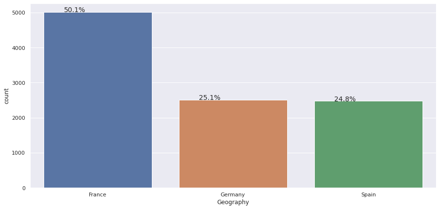

```python
#Geography
perc_on_bar(dataCC['Geography'])
```

- Highest number of data points for France (50%)
- Germany and Spain have almost same number of data points (25.1% and 24.8%)

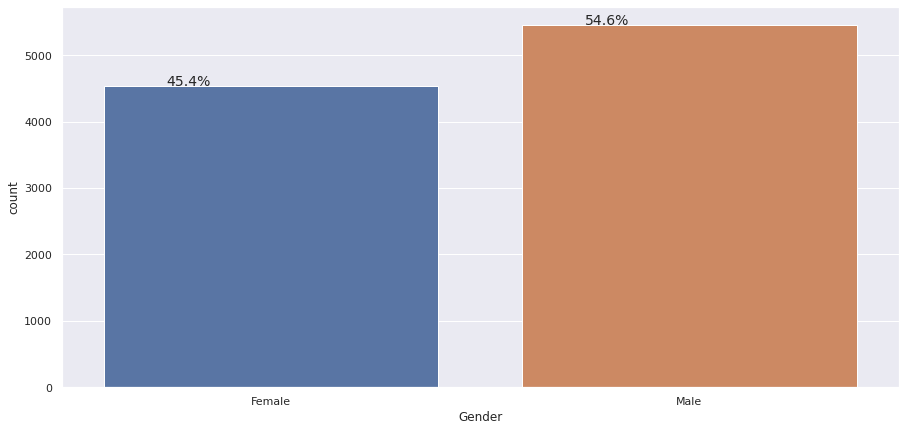

```python
#Gender
perc_on_bar(dataCC['Gender'])
```

- More number of data points for Male compared to Female

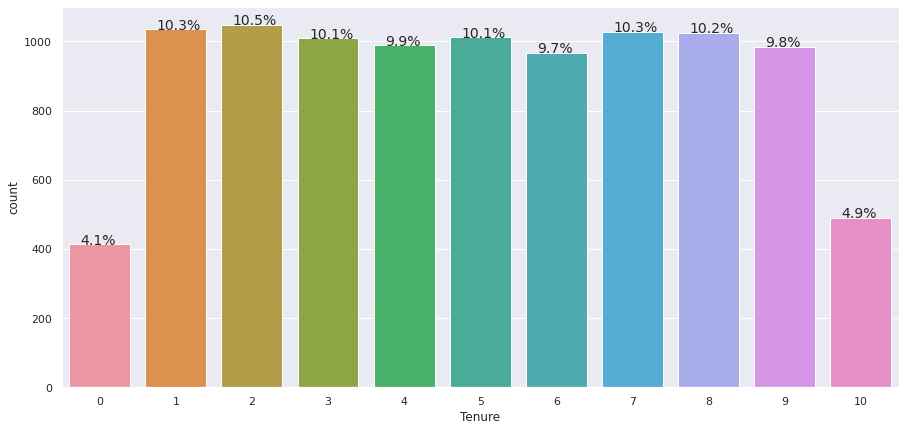

```python
#Tenure
perc_on_bar(dataCC['Tenure'])
```

- Tenure 0 and 10 have less number of data points, all other tenure values seem to have almost same % of data points
- As mentioned earlier, Tenure 0 has 413 data points, data description does not say if this months or years, since there are 413 data points, I assume we need to keep these data points with tenure = 0 and it could be tenure in years

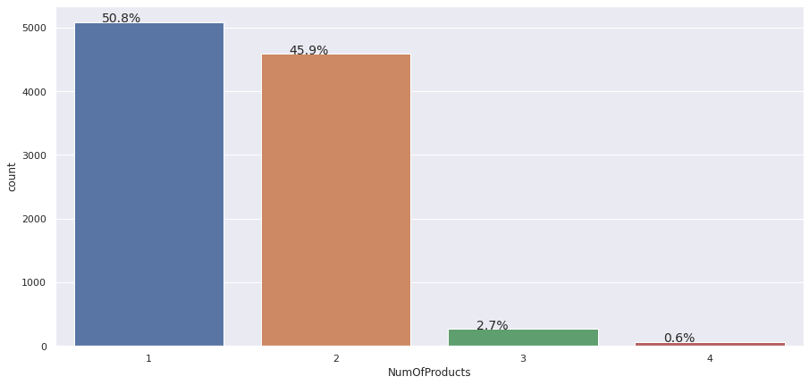

```python
#NumOfProducts
perc_on_bar(dataCC['NumOfProducts'])
```

- More customers have 1 or 2 products, number of customers having 3 or 4 products is less

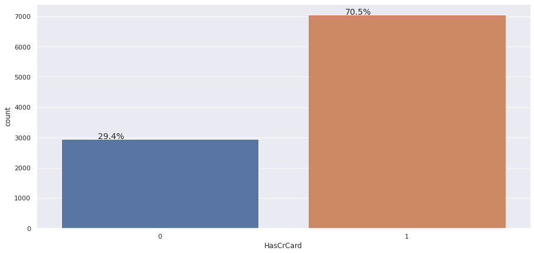

```python
#HasCrCard
perc_on_bar(dataCC['HasCrCard'])
```

- Number of customers having Credit Card is more than those do not have CC.

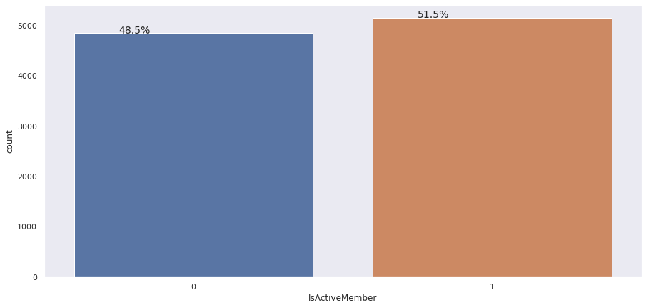

```python
#IsActiveMember
perc_on_bar(dataCC['IsActiveMember'])
```

- Binary variable, shows almost same count for active and non-active (not a big difference)

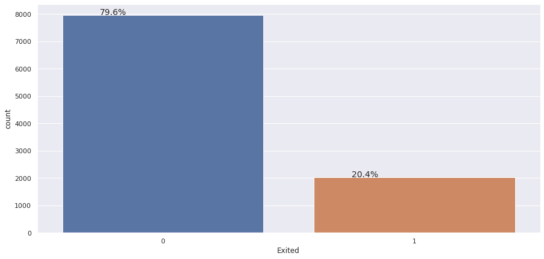

```python
#Exited
perc_on_bar(dataCC['Exited'])
```

- This is our target variable, number or % of customers who left the bank is very less compared to the number of customers who continue to use bank services

##### **EDA - Bivariate Analysis**

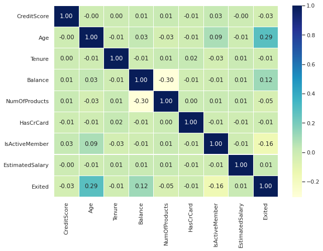

```python
#Heatmap to visualize the relationship between non-categorical variables
fig, ax = plt.subplots(figsize=(10,7));
sns.heatmap(dataCC.corr(),annot=True,linewidths=0.1,cmap='YlGnBu',fmt='.2f');
```

- Age has a small positive correlation with target variable Exited
- Balance has a small -ve correlation with NumberOfProducts
- Balance has also a very small positive correlation with target variable Exited
- IsActiveMember has a small -ve correlation with target variable Exited

##### **Pairplot for pairwise analysis and density plot of individual features**

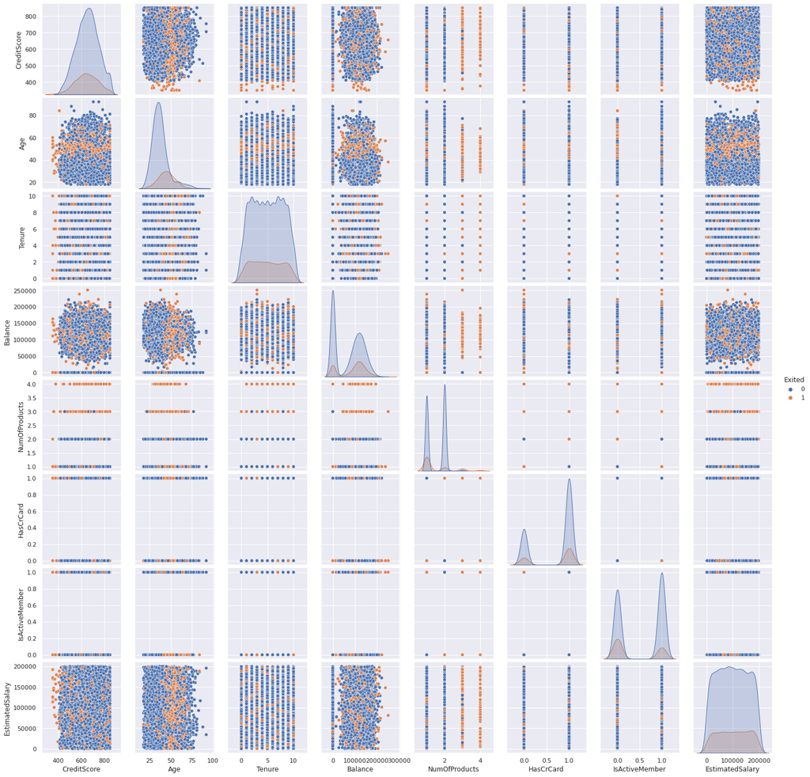

```python
#Pairplot for the dataset
sns.pairplot(data=dataCC,diag_kind='kde',hue='Exited');
```

- Pairplot also shows the same relationsships b/w variables that we saw in heatmap
- No clear linear relationship is shows in both heatmap or pairplot
- It clearly shows there are very less data points for 'Exited' true

```python
#Bivariate Analysis - let us look at how target variable (Exited) is distributed amongst continuous variables
numeric_cols = ['CreditScore','Age','Balance','EstimatedSalary','Exited']
dataCC[numeric_cols].groupby(['Exited']).mean()
```

| Exited | CreditScore | Age | Balance | EstimatedSalary |
| --- | --- | --- | --- | --- |
| 0 | 651.853196 | 37.408389 | 72745.296779 | 99738.391772 |
| 1 | 645.351497 | 44.837997 | 91108.539337 | 101465.677531 |

```python
dataCC[numeric_cols].groupby(['Exited']).median()
```

| Exited | CreditScore | Age | Balance | EstimatedSalary |
| --- | --- | --- | --- | --- |
| 0 | 653 | 36 | 92072.68 | 99645.04 |
| 1 | 646 | 45 | 109349.29 | 102460.84 |

- When we see mean and median of continuos variables with respect to the target variable, these features seem to have no major difference between the two categories (Exited and Not Exited)
- Mean and Median Balance slightly more for Exited customers
- Mean and Median EsimatedSalary slightly more for Exited customers
- Mean and Median CreditScore slightly more for Not-Exited class
- Mean and Median Age slightly more for Exited customers

```python
#Bivariate Analysis - let us look at how target variable (Exited) is distributed amongst categorical variables
pd.crosstab(dataCC['Geography'],dataCC['Exited'],normalize='index')
```

| Exited Geography | 0 | 1 |
| --- | --- | --- |
| France | 0.838452 | 0.161548 |
| Germany | 0.675568 | 0.324432 |
| Spain | 0.833266 | 0.166734 |

- % of Exited customers seem to be more in Germany compared to other two locations
- Or % of not-exited customers seem to be less in Germany compared to other two locations

```python
pd.crosstab(dataCC['Gender'],dataCC['Exited'],normalize='index')
```

| Exited Gender | 0 | 1 |
| --- | --- | --- |
| Female | 0.749285 | 0.250715 |
| Male | 0.835441 | 0.164559 |

- % of Exited customers seem to be more in Females

```python
pd.crosstab(dataCC['Tenure'],dataCC['Exited'],normalize='index')
```

| Exited Tenure | 0 | 1 |
| --- | --- | --- |
| 0 | 0.769976 | 0.230024 |
| 1 | 0.775845 | 0.224155 |
| 2 | 0.808206 | 0.191794 |
| 3 | 0.788900 | 0.211100 |
| 4 | 0.794742 | 0.205258 |
| 5 | 0.793478 | 0.206522 |
| 6 | 0.797311 | 0.202689 |
| 7 | 0.827821 | 0.172179 |
| 8 | 0.807805 | 0.192195 |
| 9 | 0.783537 | 0.216463 |
| 10 | 0.793878 | 0.206122 |

- Tenure does not seem to have an impact on target variable
- % of Exited Vs Non-exited customers seem to be same across different tenures

```python
pd.crosstab(dataCC['NumOfProducts'],dataCC['Exited'],normalize='index')
```

| Exited NumOfProducts | 0 | 1 |
| --- | --- | --- |
| 1 | 0.722856 | 0.277144 |
| 2 | 0.924183 | 0.075817 |
| 3 | 0.172932 | 0.827068 |
| 4 | 0.000000 | 1.000000 |

- % of Exited customers seem to be high when customers own 3 or 4 products

```python
pd.crosstab(dataCC['HasCrCard'],dataCC['Exited'],normalize='index')
```

| Exited HasCrCard | 0 | 1 |
| --- | --- | --- |
| 0 | 0.791851 | 0.208149 |
| 1 | 0.798157 | 0.201843 |

- HasCrCard does not seem to have an impact on target variable
- % of Exited Vs Non-exited customers seem to be same across customers with CC and customers without CC

```python
pd.crosstab(dataCC['IsActiveMember'],dataCC['Exited'],normalize='index')
```

| Exited IsActiveMember | 0 | 1 |
| --- | --- | --- |
| 0 | 0.731491 | 0.268509 |
| 1 | 0.857309 | 0.142691 |

- % of Exited customers seem to be more when IsActiveMember flag is 0
- This makes sense, when a member is active, chances are that the member is going to keep using bank services

##### **Let us explore the correlation between variables (other than target variable) that we saw in heatmap**

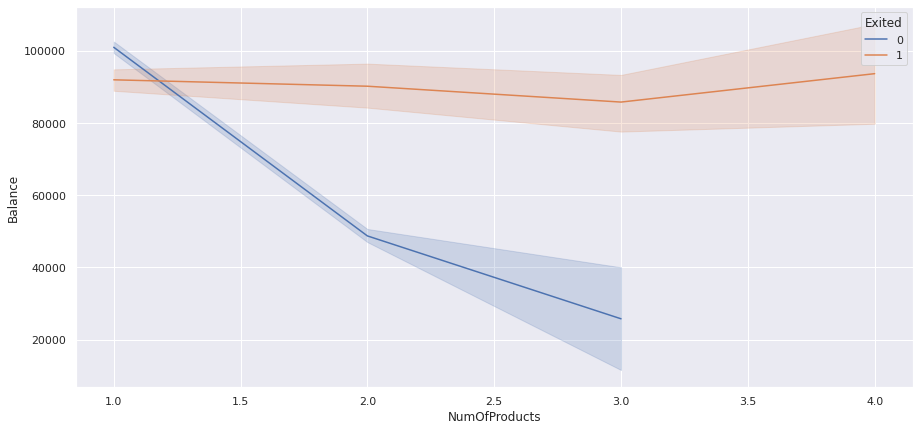

```python
#Balance Vs NumberOfProducts
sns.lineplot(y=dataCC.Balance, x=dataCC.NumOfProducts, hue=dataCC.Exited);
```

- For exited customers, after 3 products, it shows slight increase in Balance with Number of products
- For non-exited class, there is a -ve relationship between the two

##### **Exited Vs continuous variables**

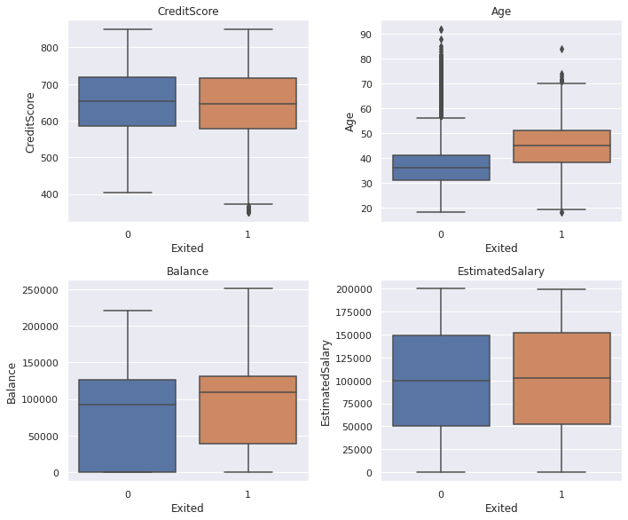

```python
#Bivariate plot for numeric variables and target variable
cols = dataCC[
    [
        'CreditScore',
        'Age',
        'Balance',
        'EstimatedSalary'

    ]
].columns.tolist()
plt.figure(figsize=(10, 20))

for i, variable in enumerate(cols):
    plt.subplot(5, 2, i + 1)
    sns.boxplot(dataCC["Exited"], dataCC[variable])
    plt.tight_layout()
    plt.title(variable)
plt.show()
```

Lets try the same without outliers, so removing outliers (for visualization not from orignal data) to get a better understanding

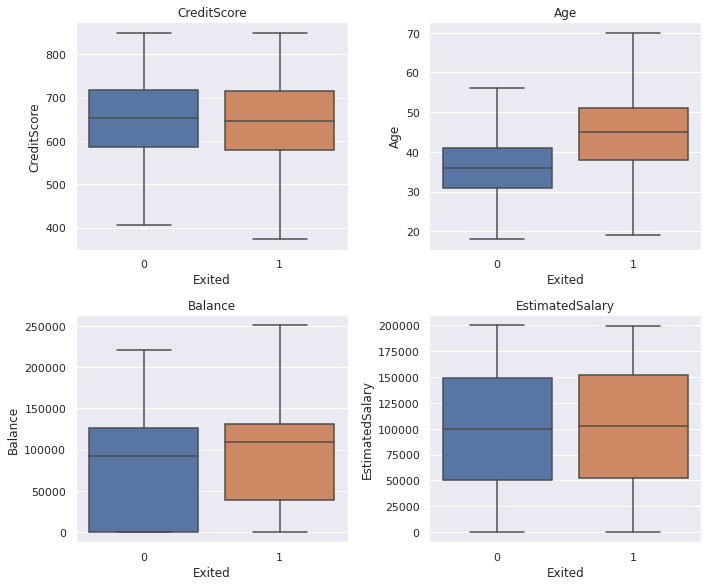

```python
cols = dataCC[
    [
        'CreditScore',
        'Age',
        'Balance',
        'EstimatedSalary'

    ]
].columns.tolist()
plt.figure(figsize=(10, 20))

for i, variable in enumerate(cols):
    plt.subplot(5, 2, i + 1)
    sns.boxplot(dataCC["Exited"], dataCC[variable],showfliers=False)
    plt.tight_layout()
    plt.title(variable)
plt.show()
```

- Similar to the analysis done using median and mean, the boxplots also show that the target variable is not much impacted by CreditScore, EstimatedSalary (credit score slightly lower for Exited =1, EstimatedSalary slightly higher for Exited =1)
- Age slightly more for Exited =1 customers
- 25% and 50% Balance seem to be more for Exited =1 customers

#### **Exited Vs categorical variables**

```python
#Function to get count plot with hue, that shows % among each class
#Shows crosstab again for better readability and to show % within class and different classes altogether
def perc_on_bar_with_hue(x):
    tab1 = pd.crosstab(dataCC[x],dataCC['Exited'],margins=True)
    print(tab1)
    print('-'*80)
    df1 = dataCC.groupby(x)['Exited'].value_counts(normalize=True)
    df1 = df1.mul(100)
    df1 = df1.rename('percent').reset_index()

    g = sns.catplot(x=x,y='percent',hue='Exited',kind='bar',data=df1,aspect=2.0)
    g.ax.set_ylim(0,100)

    for p in g.ax.patches:
        #print(p)
        height = p.get_height()
        if np.isnan(height):
            height = 0
        txt = str(round(height,2)) + '%'
        txt_x = p.get_x()
        txt_y = height
        g.ax.text(txt_x,txt_y,txt)
```

```
Exited        0     1    All
Geography
France     4204   810   5014
Germany    1695   814   2509
Spain      2064   413   2477
All        7963  2037  10000
--------------------------------------------------------------------------------
```

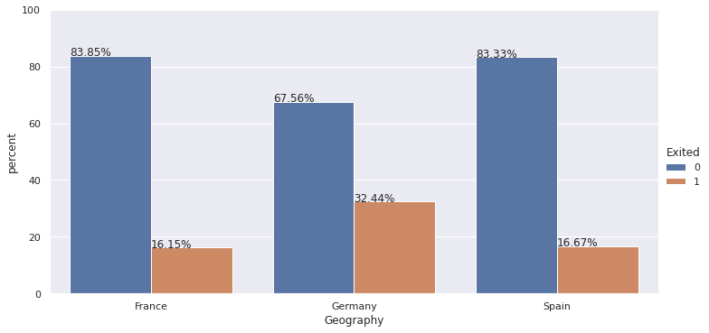

```python
#Geography Vs Exited
perc_on_bar_with_hue('Geography')
```

- % of Exited customers seem to be higher for Germany
- Even though data points are more for France, % of Exited Vs not-Exited seem to be same for France and Spain

```
Exited     0     1    All
Gender
Female  3404  1139   4543
Male    4559   898   5457
All     7963  2037  10000
--------------------------------------------------------------------------------
```

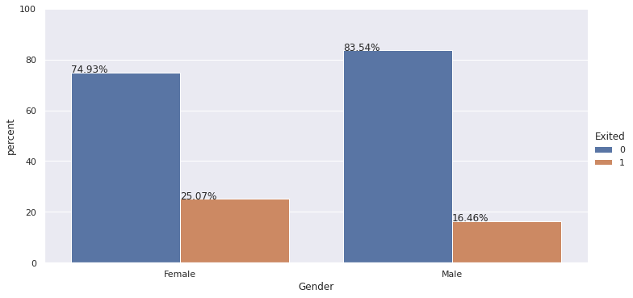

```python
#Gender Vs Exited
perc_on_bar_with_hue('Gender')
```

- % of Exited customers seem to be higher in Females

```
Exited     0     1    All
Tenure
0        318    95    413
1        803   232   1035
2        847   201   1048
3        796   213   1009
4        786   203    989
5        803   209   1012
6        771   196    967
7        851   177   1028
8        828   197   1025
9        771   213    984
10       389   101    490
All     7963  2037  10000
--------------------------------------------------------------------------------
```

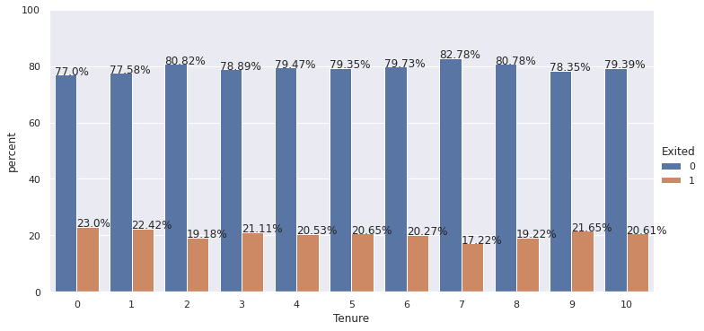

```python
#Tenure Vs Exited
perc_on_bar_with_hue('Tenure')
```

- Tenure does not seem to have an impact on target variable
- % of Exited Vs Non-exited customers seem to be same across different tenures

```
Exited            0     1    All
NumOfProducts
1              3675  1409   5084
2              4242   348   4590
3                46   220    266
4                 0    60     60
All            7963  2037  10000
--------------------------------------------------------------------------------
```

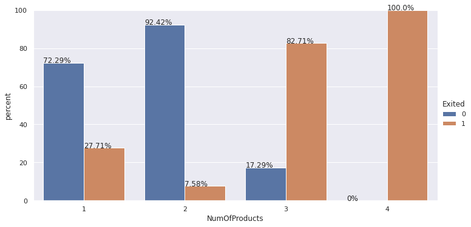

```python
#NumOfProducts Vs Exited
perc_on_bar_with_hue('NumOfProducts')
```

- % of Exited customers seem to be high when customers own 3 or 4 products

```
Exited        0     1    All
HasCrCard
0          2332   613   2945
1          5631  1424   7055
All        7963  2037  10000
--------------------------------------------------------------------------------
```

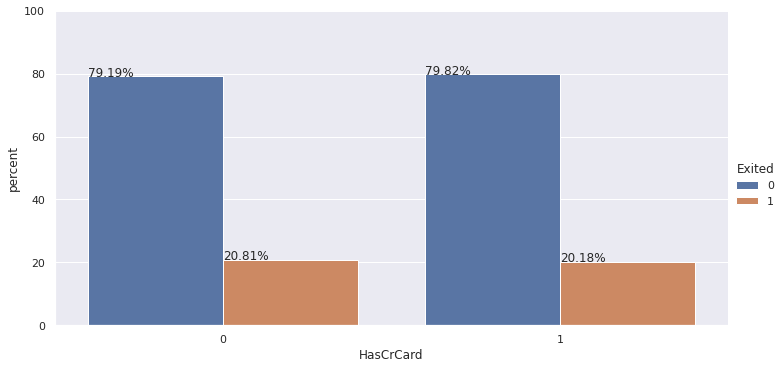

```python
#HasCrCard Vs Exited
perc_on_bar_with_hue('HasCrCard')
```

- HasCrCard does not seem to have an impact on target variable
- % of Exited Vs Non-exited customers seem to be same across customers with CC and customers without CC

```
Exited             0     1    All
IsActiveMember
0               3547  1302   4849
1               4416   735   5151
All             7963  2037  10000
--------------------------------------------------------------------------------
```

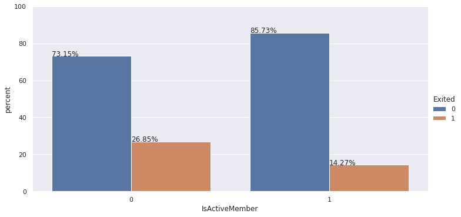

```python
#IsActiveMember Vs Exited
perc_on_bar_with_hue('IsActiveMember')
```

- % of Exited customers seem to be more when IsActiveMember flag is 0
- This makes sense, when a member is active, chances are that the member is going to keep using bank services

#### **Customer profile for different features**

- Below are 3 different customer profiles
  - Exited customers profile based on Geography and Gender
  - Not-exited customers profile based on Geography and Gender
  - Customer profile for exited Vs not-exited
- These profiles are going to show Mode (most frequent value in the group) for Geography, Gender, Tenure, NumOfProducts, HasCrCard and IsActiveMember
- For Age, profiles are going to show median for the group
- For CreditScore, Balance and EstimatedSalary profiles are going to show Mean or Average for the group

###### **Exited customers**

- Based on Geography

```python
df = dataCC[(dataCC['Exited'] == 1)]
df1 = df[['Age','CreditScore','Balance','EstimatedSalary','Tenure','NumOfProducts','HasCrCard','IsActiveMember','Geography','Gender']]
df1.groupby(['Geography']).agg(Gender  = ('Gender', \
                                        lambda x: x.value_counts().index[0]),
                                    Tenure  = ('Tenure', \
                                        lambda x: x.value_counts().index[0]),
                                    NumOfProducts  = ('NumOfProducts', \
                                        lambda x: x.value_counts().index[0]),
                                    HasCrCard  = ('HasCrCard', \
                                        lambda x: x.value_counts().index[0]),
                                    IsActiveMember  = ('IsActiveMember', \
                                        lambda x: x.value_counts().index[0]),
                                        Avg_credit_score = ('CreditScore','mean'),
                                        Avg_balance = ('Balance','mean'),
                                        Avg_estimated_salary = ('EstimatedSalary','mean'),
                                        Median_age = ('Age', 'median') \

                                      )
```

| Geography | Gender | Tenure | NumOfProducts | HasCrCard | IsActiveMember | Avg_credit_score | Avg_balance | Avg_estimated_salary | Median_age |
| --- | --- | --- | --- | --- | --- | --- | --- | --- | --- |
| France | Female | 2 | 1 | 1 | 0 | 641.914815 | 71192.795728 | 103439.278296 | 45 |
| Germany | Female | 1 | 1 | 1 | 0 | 647.689189 | 120361.075590 | 98403.886450 | 45 |
| Spain | Female | 2 | 1 | 1 | 0 | 647.484262 | 72513.352446 | 103629.554818 | 44 |

- Based on Gender

```python
df = dataCC[(dataCC['Exited'] == 1)]
df1 = df[['Age','CreditScore','Balance','EstimatedSalary','Tenure','NumOfProducts','HasCrCard','IsActiveMember','Geography','Gender']]
df1.groupby(['Gender']).agg(Geography  = ('Geography', \
                                        lambda x: x.value_counts().index[0]),
                                    Tenure  = ('Tenure', \
                                        lambda x: x.value_counts().index[0]),
                                    NumOfProducts  = ('NumOfProducts', \
                                        lambda x: x.value_counts().index[0]),
                                    HasCrCard  = ('HasCrCard', \
                                        lambda x: x.value_counts().index[0]),
                                    IsActiveMember  = ('IsActiveMember', \
                                        lambda x: x.value_counts().index[0]),
                                        Avg_credit_score = ('CreditScore','mean'),
                                        Avg_balance = ('Balance','mean'),
                                        Avg_estimated_salary = ('EstimatedSalary','mean'),
                                        Median_age = ('Age', 'median') \

                                      )
```

| Gender | Geography | Tenure | NumOfProducts | HasCrCard | IsActiveMember | Avg_credit_score | Avg_balance | Avg_estimated_salary | Median_age |
| --- | --- | --- | --- | --- | --- | --- | --- | --- | --- |
| Female | France | 1 | 1 | 1 | 0 | 646.883231 | 89036.639359 | 102948.986093 | 45 |
| Male | Germany | 9 | 1 | 1 | 0 | 643.408686 | 93736.483742 | 99584.287272 | 45 |

###### **Existing customers**

- Based on Geography

```python
df = dataCC[(dataCC['Exited'] == 0)]
df1 = df[['Age','CreditScore','Balance','EstimatedSalary','Tenure','NumOfProducts','HasCrCard','IsActiveMember','Geography','Gender']]
df1.groupby(['Geography']).agg(Gender  = ('Gender', \
                                        lambda x: x.value_counts().index[0]),
                                    Tenure  = ('Tenure', \
                                        lambda x: x.value_counts().index[0]),
                                    NumOfProducts  = ('NumOfProducts', \
                                        lambda x: x.value_counts().index[0]),
                                    HasCrCard  = ('HasCrCard', \
                                        lambda x: x.value_counts().index[0]),
                                    IsActiveMember  = ('IsActiveMember', \
                                        lambda x: x.value_counts().index[0]),
                                        Avg_credit_score = ('CreditScore','mean'),
                                        Avg_balance = ('Balance','mean'),
                                        Avg_estimated_salary = ('EstimatedSalary','mean'),
                                        Median_age = ('Age', 'median') \

                                      )
```

| Geography | Gender | Tenure | NumOfProducts | HasCrCard | IsActiveMember | Avg_credit_score | Avg_balance | Avg_estimated_salary | Median_age |
| --- | --- | --- | --- | --- | --- | --- | --- | --- | --- |
| France | Male | 7 | 2 | 1 | 1 | 651.162226 | 60339.275678 | 99217.097331 | 36 |
| Germany | Male | 2 | 2 | 1 | 1 | 653.261357 | 119427.106696 | 102414.657876 | 36 |
| Spain | Male | 8 | 2 | 1 | 1 | 652.104167 | 59678.070470 | 98602.369864 | 36 |

- Based on Gender

```python
df = dataCC[(dataCC['Exited'] == 0)]
df1 = df[['Age','CreditScore','Balance','EstimatedSalary','Tenure','NumOfProducts','HasCrCard','IsActiveMember','Geography','Gender']]
df1.groupby(['Gender']).agg(Geography  = ('Geography', \
                                        lambda x: x.value_counts().index[0]),
                                    Tenure  = ('Tenure', \
                                        lambda x: x.value_counts().index[0]),
                                    NumOfProducts  = ('NumOfProducts', \
                                        lambda x: x.value_counts().index[0]),
                                    HasCrCard  = ('HasCrCard', \
                                        lambda x: x.value_counts().index[0]),
                                    IsActiveMember  = ('IsActiveMember', \
                                        lambda x: x.value_counts().index[0]),
                                        Avg_credit_score = ('CreditScore','mean'),
                                        Avg_balance = ('Balance','mean'),
                                        Avg_estimated_salary = ('EstimatedSalary','mean'),
                                        Median_age = ('Age', 'median') \

                                      )
```

| Gender | Geography | Tenure | NumOfProducts | HasCrCard | IsActiveMember | Avg_credit_score | Avg_balance | Avg_estimated_salary | Median_age |
| --- | --- | --- | --- | --- | --- | --- | --- | --- | --- |
| Female | France | 2 | 2 | 1 | 1 | 652.152468 | 71183.249639 | 99816.071486 | 36 |
| Male | France | 8 | 2 | 1 | 1 | 651.629743 | 73911.607037 | 99680.391827 | 36 |

##### **Exited Vs Existing customers profile**

```python
df = dataCC
df1 = df[['Exited','Age','CreditScore','Balance','EstimatedSalary','Tenure','NumOfProducts','HasCrCard','IsActiveMember','Geography','Gender']]
df1.groupby(['Exited']).agg(Geography  = ('Geography', \
                                        lambda x: x.value_counts().index[0]),
                                    Gender  = ('Gender', \
                                        lambda x: x.value_counts().index[0]),
                                    Tenure  = ('Tenure', \
                                        lambda x: x.value_counts().index[0]),
                                    NumOfProducts  = ('NumOfProducts', \
                                        lambda x: x.value_counts().index[0]),
                                    HasCrCard  = ('HasCrCard', \
                                        lambda x: x.value_counts().index[0]),
                                    IsActiveMember  = ('IsActiveMember', \
                                        lambda x: x.value_counts().index[0]),
                                        Avg_credit_score = ('CreditScore','mean'),
                                        Avg_balance = ('Balance','mean'),
                                        Avg_estimated_salary = ('EstimatedSalary','mean'),
                                        Median_age = ('Age', 'median') \

                                      )
```

| Exited | Geography | Gender | Tenure | NumOfProducts | HasCrCard | IsActiveMember | Avg_credit_score | Avg_balance | Avg_estimated_salary | Median_age |
| --- | --- | --- | --- | --- | --- | --- | --- | --- | --- | --- |
| 0 | France | Male | 7 | 2 | 1 | 1 | 651.853196 | 72745.296779 | 99738.391772 | 36 |
| 1 | Germany | Female | 1 | 1 | 1 | 0 | 645.351497 | 91108.539337 | 101465.677531 | 45 |

#### **Insights based on EDA**

###### **Key meaningful observations on the relationship between variables**

- Geography seems to have an impact on exited customer %. Exited % is higher for Germany, compared to other 2 locations.
- Gender seems to have an impact on exited customer %. Exited % is higher in Females.
- Tenure period does not seem to have an impact on Exited %. Exited Vs Non-exited customers % seem to be same across different tenures.
- Number of Products seem to have an impact on Exited %. Exited % is high for customers having Number of Products 3 and 4.
- HasCrCard does not seem to have an impact on Exited %. Exited Vs Non-exited customers % seem to be same across customers with CC and customers without CC.
- % of Exited customers seem to be more when IsActiveMember flag is 0. This makes sense, when a member is active, chances are that the member is going to keep using bank services.
- Bivariate anaysis shows that target variable (Exited) is not much impacted by CreditScore and EstimatedSalary. Avg Credit Score slightly lower for Exited customers, which makes sense, customers with less credit score may not be getting more services from bank and hence there is possibility for them to leave. Avg Estimated Salary bit high for Exited customers.
- Age slightly more for customers who left the bank services compared to customers who continue to use bank services.
- 25th percentile and 50th percentile for Balance seem to be more for customers who left the bank services compared to customers who continue to use bank services. Avg Balance also shows bit high for Exited customers.
- From heatmap bivariate analysis, Age shows a small positive correlation with target variable Exited.
- From heatmap bivariate analysis, Balance shows a small -ve correlation with NumberOfProducts.
- From heatmap bivariate analysis, Balance also shows a very small positive correlation with target variable Exited.
- From heatmap bivariate analysis, IsActiveMember shows a small -ve correlation with target variable Exited.

**Should we do PCA??**

- PCA can be used to reduce dimensions, if the dataset has too many variables and there is a possibility of 'curse of dimensionality'
- PCA can also be used to remove multicollinearity to make the variables independent
- In the given dataset, from pairplot and heatmap, we have seen that, there are no strong correlation between variables
- And there are only 11 variables in this given dataset, after removing ID columns
- Considering these points, I believe, we do not need to do PCA for dimensionality reduction

##### **Data Pre-processing**

- RowNumber column removed since that is just an ID column and not going to add value to the model
- CustomerId column removed since that is just an ID column and not going to add value to the model
- Surname column removed since that is just customer name and not going to have any value to the model
- Missing (null) value check is done on all columns and no nulls are present in the dataset
- Outliers are present in Age and CreditScore, they were explained in the univariate analysis .Since those values are not standing out from the rest of the data, they are not removed
- Target variable (Exited) is a categorical column and need to be converted to category before building the model
- None of the columns in this dataset shows a very strong correlation with the target variable, so decided to keep all features for model building
- All features are in different scales, so need to scale or normalize these features before model building.
- Categorical column need to be one-hot encoded before model building.

```python
#Converting target variabe to category
#dataCC['Exited'] = dataCC['Exited'].astype('category')
```

```python
#Checking info to see the data types
dataCC.info()
```

```
<class 'pandas.core.frame.DataFrame'>
RangeIndex: 10000 entries, 0 to 9999
Data columns (total 11 columns):
 #   Column           Non-Null Count  Dtype
---  ------           --------------  -----
 0   CreditScore      10000 non-null  int64
 1   Geography        10000 non-null  category
 2   Gender           10000 non-null  category
 3   Age              10000 non-null  int64
 4   Tenure           10000 non-null  int64
 5   Balance          10000 non-null  float64
 6   NumOfProducts    10000 non-null  int64
 7   HasCrCard        10000 non-null  int64
 8   IsActiveMember   10000 non-null  int64
 9   EstimatedSalary  10000 non-null  float64
 10  Exited           10000 non-null  int64
dtypes: category(2), float64(2), int64(7)
memory usage: 723.0 KB
```

```python
#Checking columns that contain zeros
for col in dataCC.drop('Exited',axis=1).columns:
    if (dataCC[col] == 0).any() == True:
        print('{} has one or more zeros'.format(col))
```

```
Tenure has one or more zeros
Balance has one or more zeros
HasCrCard has one or more zeros
IsActiveMember has one or more zeros
```

- The above 4 columns have zeros, but they are features that can have zeros in real world scenarios, hence not imputing them
- HasCrCard and IsActiveMember are binary and have 0 or 1
- Balance can be zero in real world scenario
- Tenure has 0, data description does not say if this is months or years, since there are 413 data points, I assume we need to keep these data points with tenure = 0 and it could be tenure in years.

##### **One-hot encoding for categorical columns**

```python
#One hot encoding for string columns
oneHotCols=['Geography','Gender']
```

```python
dataCC = pd.get_dummies(dataCC, columns=oneHotCols,drop_first=True)
dataCC.head(10)
```

|  | CreditScore | Age | Tenure | Balance | NumOfProducts | HasCrCard | IsActiveMember | EstimatedSalary | Exited | Geography_Germany | Geography_Spain | Gender_Male |
| --- | --- | --- | --- | --- | --- | --- | --- | --- | --- | --- | --- | --- |
| 0 | 619 | 42 | 2 | 0.00 | 1 | 1 | 1 | 101348.88 | 1 | 0 | 0 | 0 |
| 1 | 608 | 41 | 1 | 83807.86 | 1 | 0 | 1 | 112542.58 | 0 | 0 | 1 | 0 |
| 2 | 502 | 42 | 8 | 159660.80 | 3 | 1 | 0 | 113931.57 | 1 | 0 | 0 | 0 |
| 3 | 699 | 39 | 1 | 0.00 | 2 | 0 | 0 | 93826.63 | 0 | 0 | 0 | 0 |
| 4 | 850 | 43 | 2 | 125510.82 | 1 | 1 | 1 | 79084.10 | 0 | 0 | 1 | 0 |
| 5 | 645 | 44 | 8 | 113755.78 | 2 | 1 | 0 | 149756.71 | 1 | 0 | 1 | 1 |
| 6 | 822 | 50 | 7 | 0.00 | 2 | 1 | 1 | 10062.80 | 0 | 0 | 0 | 1 |
| 7 | 376 | 29 | 4 | 115046.74 | 4 | 1 | 0 | 119346.88 | 1 | 1 | 0 | 0 |
| 8 | 501 | 44 | 4 | 142051.07 | 2 | 0 | 1 | 74940.50 | 0 | 0 | 0 | 1 |
| 9 | 684 | 27 | 2 | 134603.88 | 1 | 1 | 1 | 71725.73 | 0 | 0 | 0 | 1 |

```python
#Keep column names in a variable for future use
column_names = list(dataCC.columns)
column_names.remove('Exited')
feature_names = column_names
print(feature_names)
```

```
['CreditScore', 'Age', 'Tenure', 'Balance', 'NumOfProducts', 'HasCrCard', 'IsActiveMember', 'EstimatedSalary', 'Geography_Germany', 'Geography_Spain', 'Gender_Male']
```

##### **Split the target variable and predictors**

```python
X = dataCC.drop('Exited',axis=1)
y = dataCC['Exited']
```

```python
X.head()
```

|  | CreditScore | Age | Tenure | Balance | NumOfProducts | HasCrCard | IsActiveMember | EstimatedSalary | Geography_Germany | Geography_Spain | Gender_Male |
| --- | --- | --- | --- | --- | --- | --- | --- | --- | --- | --- | --- |
| 0 | 619 | 42 | 2 | 0.00 | 1 | 1 | 1 | 101348.88 | 0 | 0 | 0 |
| 1 | 608 | 41 | 1 | 83807.86 | 1 | 0 | 1 | 112542.58 | 0 | 1 | 0 |
| 2 | 502 | 42 | 8 | 159660.80 | 3 | 1 | 0 | 113931.57 | 0 | 0 | 0 |
| 3 | 699 | 39 | 1 | 0.00 | 2 | 0 | 0 | 93826.63 | 0 | 0 | 0 |
| 4 | 850 | 43 | 2 | 125510.82 | 1 | 1 | 1 | 79084.10 | 0 | 1 | 0 |

```python
y.head()
```

```
0    1
1    0
2    1
3    0
4    0
Name: Exited, dtype: int64
```

```python
#printing the shape of the data
print(y.shape)
print(X.shape)
```

```
(10000,)
(10000, 11)
```

##### **Split the data into train and test**

```python
#Split the dataset into 80% train and 20% test set
X_train, X_test, y_train, y_test =train_test_split(X, y, test_size=0.2, random_state=7,stratify=y)
```

```python
#printing the shape of the data
print(X_train.shape, X_test.shape)
print(y_train.shape, y_test.shape)
```

```
(8000, 11) (2000, 11)
(8000,) (2000,)
```

##### **Scale the data using MinMaxScaler**

- Data scaling is done after train,test split to prevent data leakage
- Scaling is done for continuous columns only, binary features are not scaled
- Since the binary columns are having values 0 or 1, doing Min-Max scaler for other columns, to give them the same minimum of zero, max of one, range of 1

```python
scaler = MinMaxScaler()
X_train[['CreditScore','Age','Tenure','Balance','NumOfProducts','EstimatedSalary']] = scaler.fit_transform(X_train[['CreditScore','Age','Tenure','Balance','NumOfProducts','EstimatedSalary']])
X_test[['CreditScore','Age','Tenure','Balance','NumOfProducts','EstimatedSalary']] = scaler.transform(X_test[['CreditScore','Age','Tenure','Balance','NumOfProducts','EstimatedSalary']])
```

```python
#Creating a dataframe from the scaled data above
X_train = pd.DataFrame(X_train,columns=feature_names)
X_test = pd.DataFrame(X_test,columns=feature_names)
```

```python
X_train.head()
```

|  | CreditScore | Age | Tenure | Balance | NumOfProducts | HasCrCard | IsActiveMember | EstimatedSalary | Geography_Germany | Geography_Spain | Gender_Male |
| --- | --- | --- | --- | --- | --- | --- | --- | --- | --- | --- | --- |
| 4858 | 0.858 | 0.310811 | 1.0 | 0.397716 | 0.000000 | 1 | 0 | 0.434621 | 0 | 0 | 0 |
| 1733 | 0.528 | 0.189189 | 0.7 | 0.396427 | 0.333333 | 1 | 1 | 0.255552 | 1 | 0 | 1 |
| 7073 | 0.658 | 0.297297 | 0.1 | 0.000000 | 0.000000 | 1 | 1 | 0.084436 | 0 | 0 | 1 |
| 9864 | 0.784 | 0.202703 | 0.1 | 0.549777 | 0.000000 | 1 | 1 | 0.256902 | 1 | 0 | 1 |
| 438 | 0.900 | 0.270270 | 0.2 | 0.670353 | 0.333333 | 1 | 0 | 0.340235 | 0 | 0 | 0 |

```python
X_test.head()
```

|  | CreditScore | Age | Tenure | Balance | NumOfProducts | HasCrCard | IsActiveMember | EstimatedSalary | Geography_Germany | Geography_Spain | Gender_Male |
| --- | --- | --- | --- | --- | --- | --- | --- | --- | --- | --- | --- |
| 8443 | 0.538 | 0.067568 | 0.5 | 0.529000 | 0.000000 | 1 | 1 | 0.719577 | 1 | 0 | 1 |
| 3573 | 0.640 | 0.675676 | 0.4 | 0.000000 | 0.333333 | 1 | 1 | 0.057081 | 0 | 0 | 1 |
| 7047 | 0.870 | 0.175676 | 0.2 | 0.485024 | 0.333333 | 0 | 0 | 0.408875 | 0 | 1 | 0 |
| 1535 | 0.828 | 0.202703 | 0.9 | 0.673440 | 0.000000 | 0 | 1 | 0.594911 | 0 | 1 | 0 |
| 9475 | 0.532 | 0.378378 | 0.2 | 0.000000 | 0.333333 | 1 | 0 | 0.685690 | 0 | 0 | 1 |

```python
#printing the shape of the data
print(X_train.shape, X_test.shape)
print(y_train.shape, y_test.shape)
```

```
(8000, 11) (2000, 11)
(8000,) (2000,)
```

```python
X_train.info()
```

```
<class 'pandas.core.frame.DataFrame'>
Int64Index: 8000 entries, 4858 to 2170
Data columns (total 11 columns):
 #   Column             Non-Null Count  Dtype
---  ------             --------------  -----
 0   CreditScore        8000 non-null   float64
 1   Age                8000 non-null   float64
 2   Tenure             8000 non-null   float64
 3   Balance            8000 non-null   float64
 4   NumOfProducts      8000 non-null   float64
 5   HasCrCard          8000 non-null   int64
 6   IsActiveMember     8000 non-null   int64
 7   EstimatedSalary    8000 non-null   float64
 8   Geography_Germany  8000 non-null   uint8
 9   Geography_Spain    8000 non-null   uint8
 10  Gender_Male        8000 non-null   uint8
dtypes: float64(6), int64(2), uint8(3)
memory usage: 585.9 KB
```

- Converting X_train and X_test columns to float64 type

```python
X_train = X_train.astype('float64')
X_test = X_test.astype('float64')
```

```python
X_train.dtypes
```

```
CreditScore          float64
Age                  float64
Tenure               float64
Balance              float64
NumOfProducts        float64
HasCrCard            float64
IsActiveMember       float64
EstimatedSalary      float64
Geography_Germany    float64
Geography_Spain      float64
Gender_Male          float64
dtype: object
```

##### **Model Building**

###### **Model performance evaluation criterion**

- The objective is to find out if a customer is going to leave bank services or not (churn prediction). Because customers leaving bank services would lead bank to loss, so the bank wants to analyze the data of customers and identify the customers who will leave their services.

###### **Here are the wrong predictions that the model can make**

- Predicting a customer will leave bank services and the customer does not leave
- Predicting a customer will NOT leave bank services and the customer leaves

###### **Which prediction is more important**

- In the first scenario, the model predicts customer will leave bank services, so the bank takes effort to retain them, which causes the bank more resources and money
- In the second scenario, the model predicts customer will NOT leave bank services, so the bank is not going to take any effort to retain those customers, but in real world scenario the customer leaves the serives, which causes the bank huge loss

##### **Which is the right metric for model evaluation**

- The first wrong prediction type is FP (False Positive) and the second wrong prediction type is FN(False Negative)
- Since the bank wants to avoid losses due to customers leaving bank services, we need to focus on reducing the false negatives, recall is the right metric in this case, greater the Recall lesser the chances of false negatives
- We will focus more on Recall, but also keep an eye on precision, which is the metric if our focus is on reducing false positives, in this case reducing the resources

###### **How to interpret confusion matrix for the given problem**

**True Positives:**

- Reality: A customer leaves bank services
- Model predicted: The customer will leave bank services
- Outcome: The model is good

**True Negatives:**

- Reality: A customer does not leave bank services
- Model predicted: The customer will NOT leave bank services
- Outcome: The model is good

**False Positives:**

- Reality: A customer does not leave bank services
- Model predicted: The customer will leave bank services
- Outcome: Bank will be spending more on resources trying to reatin the customers who will not leave bank services

**False Negatives:**

- Reality: A customer leaves bank services
- Model predicted: The customer will NOT leave bank services
- Outcome: Bank will face a huge loss, since they will not focus on retaining the potential customers who will leave bank services

###### **Model Evaluation**

- It is recommended to split the dataset into training,evaluation and testing and fit the model on training set, perform hyper parameter tuning on evaluation set and after finding the right set of parameters check if the model is underfit, overfit or right fit on the test set
- Here validation_split is used when fitting the model, which will split data in training set again into train and validation sets.
- Initially dataset is split into train (80% -> 8000 records) and test (20% -> 2000 records). Then validation_split = 0.2 will split training set into train (80% of 80000 -> 6400 records) and validation (20% of 8000 -> 1600 records).
- Validation set is used to calculate the accuracy at the end of each epoch
- Once all epochs are complete and when the model is ready for final evaluation, test set is used to find the testing accuracy.

**Function to produce confusion matrix in a more readable format**

```python
def make_confusion_matrix(cf,
                          group_names=None,
                          categories='auto',
                          count=True,
                          percent=True,
                          cbar=True,
                          xyticks=True,
                          xyplotlabels=True,
                          sum_stats=True,
                          figsize=None,
                          cmap='Blues',
                          title=None):
    '''
    This function will make a pretty plot of an sklearn Confusion Matrix cm using a Seaborn heatmap visualization.
    Arguments
    '''


    # CODE TO GENERATE TEXT INSIDE EACH SQUARE
    blanks = ['' for i in range(cf.size)]

    if group_names and len(group_names)==cf.size:
        group_labels = ["{}\n".format(value) for value in group_names]
    else:
        group_labels = blanks

    if count:
        group_counts = ["{0:0.0f}\n".format(value) for value in cf.flatten()]
    else:
        group_counts = blanks

    if percent:
        group_percentages = ["{0:.2%}".format(value) for value in cf.flatten()/np.sum(cf)]
    else:
        group_percentages = blanks

    box_labels = [f"{v1}{v2}{v3}".strip() for v1, v2, v3 in zip(group_labels,group_counts,group_percentages)]
    box_labels = np.asarray(box_labels).reshape(cf.shape[0],cf.shape[1])


    # CODE TO GENERATE SUMMARY STATISTICS & TEXT FOR SUMMARY STATS
    if sum_stats:
        #Accuracy is sum of diagonal divided by total observations
        accuracy  = np.trace(cf) / float(np.sum(cf))

        #if it is a binary confusion matrix, show some more stats
        if len(cf)==2:
            #Metrics for Binary Confusion Matrices
            precision = cf[1,1] / sum(cf[:,1])
            recall    = cf[1,1] / sum(cf[1,:])
            f1_score  = 2*precision*recall / (precision + recall)
            stats_text = "\n\nAccuracy={:0.3f}\nPrecision={:0.3f}\nRecall={:0.3f}\nF1 Score={:0.3f}".format(
                accuracy,precision,recall,f1_score)
        else:
            stats_text = "\n\nAccuracy={:0.3f}".format(accuracy)
    else:
        stats_text = ""


    # SET FIGURE PARAMETERS ACCORDING TO OTHER ARGUMENTS
    if figsize==None:
        #Get default figure size if not set
        figsize = plt.rcParams.get('figure.figsize')

    if xyticks==False:
        #Do not show categories if xyticks is False
        categories=False


    # MAKE THE HEATMAP VISUALIZATION
    plt.figure(figsize=figsize)
    sns.heatmap(cf,annot=box_labels,fmt="",cmap=cmap,cbar=cbar,xticklabels=categories,yticklabels=categories)

    if xyplotlabels:
        plt.ylabel('True label')
        plt.xlabel('Predicted label' + stats_text)
    else:
        plt.xlabel(stats_text)

    if title:
        plt.title(title)
```

**Random Forest**

- Building Random Forest model as a base line to compare NN

```python
#random forest model object
random_forest = RandomForestClassifier(n_estimators=100)
```

```python
#model fitting
random_forest.fit(X_train,y_train)
```

```
RandomForestClassifier(bootstrap=True, ccp_alpha=0.0, class_weight=None,
                       criterion='gini', max_depth=None, max_features='auto',
                       max_leaf_nodes=None, max_samples=None,
                       min_impurity_decrease=0.0, min_impurity_split=None,
                       min_samples_leaf=1, min_samples_split=2,
                       min_weight_fraction_leaf=0.0, n_estimators=100,
                       n_jobs=None, oob_score=False, random_state=None,
                       verbose=0, warm_start=False)
```

```python
#prediction on test
y_pred = random_forest.predict(X_test)
```

```python
#accuracy score on test
random_forest.score(X_test,y_test)
```

```
0.869
```

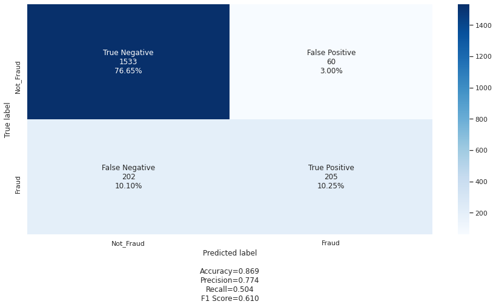

```python
#confusion matrix
cm1=confusion_matrix(y_test, y_pred)
labels = ['True Negative','False Positive','False Negative','True Positive']
categories = [ 'Not_Fraud','Fraud']
make_confusion_matrix(cm1,
                      group_names=labels,
                      categories=categories,
                      cmap='Blues')
```

- Basin random forest model gives 87% accuracy, 77% precision, 50% recall
- Lets see how NN preforms against this model

```python
#Storing Accuracy,Precision,Recall and F1-score for Model-1 in a dataframe for compare at the end
tn = cm1[0][0]
fp = cm1[0][1]
fn = cm1[1][0]
tp = cm1[1][1]

acc1 = (tp + tn) / (tp + tn + fp + fn)
precision1 = tp/(tp+fp)
recall1 = tp/(tp+fn)
f1 = 2*precision1*recall1/(precision1+recall1)

df_compare = pd.DataFrame(np.array([[acc1,precision1,recall1,f1]]),columns=['Accuracy', 'Precision', 'Recall','F1-Score'],index=['RandomForest'])
```

##### **Building NN model**

**Model-1**

- We will use a simple NN made of 4 fully-connected layers with ReLu activation. The NN takes a vector of length 11 as input. This represents 11 input columns from the dataset. The final layer will output a probability distribution (sigmoid activation function) and classify either as not Exited (0) or Exited (1).
- A dropout step is included to prevent overfitting.

```python
#initialize the model
model = Sequential()
```

**Adding layers and activations**

- Since this is a classification problem, sigmoid layer (softmax for multi-class problems, not required here) is added

```python
# This adds the input layer (input dimension) and the first hidden layer (units)
# Input has 11 columns
model.add(Dense(units=24, input_dim = 11, activation='relu'))
# hidden layer
model.add(Dense(units=16,activation='relu'))
#Adding Dropout to prevent overfitting
model.add(Dropout(0.5))
model.add(Dense(16,activation='relu'))
# Adding the output layer
# Only 1 node, since this is binary classification problem
# Sigmoid to get probability outcomes, since this is binary classification problem
model.add(Dense(1,activation='sigmoid'))
```

**Model compile with optimizers and loss functions**

```python
# Compile the model with default learning rate
model.compile(optimizer='adam',loss='binary_crossentropy',metrics=['accuracy'])
```

```python
#Model summary
model.summary()
```

```
Model: "sequential"
_________________________________________________________________
Layer (type)                 Output Shape              Param #
=================================================================
dense (Dense)                (None, 24)                288
_________________________________________________________________
dense_1 (Dense)              (None, 16)                400
_________________________________________________________________
dropout (Dropout)            (None, 16)                0
_________________________________________________________________
dense_2 (Dense)              (None, 16)                272
_________________________________________________________________
dense_3 (Dense)              (None, 1)                 17
=================================================================
Total params: 977
Trainable params: 977
Non-trainable params: 0
_________________________________________________________________
```

**Training the model [Forward pass and Backpropagation]**

```python
#fitting the model
history = model.fit(X_train,y_train,batch_size=10,epochs=15,validation_split=0.2)
```

- Plotting the train and validation loss

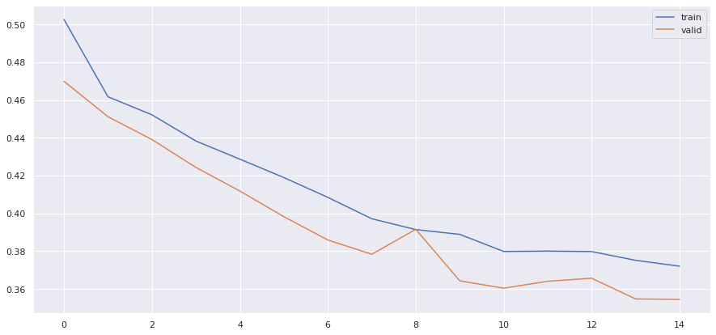

```python
# Capturing learning history per epoch
hist  = pd.DataFrame(history.history)
hist['epoch'] = history.epoch

# Plotting accuracy at different epochs
plt.plot(hist['loss'])
plt.plot(hist['val_loss'])
plt.legend(("train" , "valid") , loc =0);
```

- Both training and validation loss show continuous decrease, but shows fluctuation

**Evaluation on test**

```python
score = model.evaluate(X_test, y_test)
```

- The model achieves an accuracy of 86% in test
- Based on accuracy alone we cannot say that the model performs well
- We need to look at other measures like recall, precision etc
- Lets see the confusion matrix, ROC-AUC curve and precision-recall curve to see how well this model performs

**Confusion Matrix**

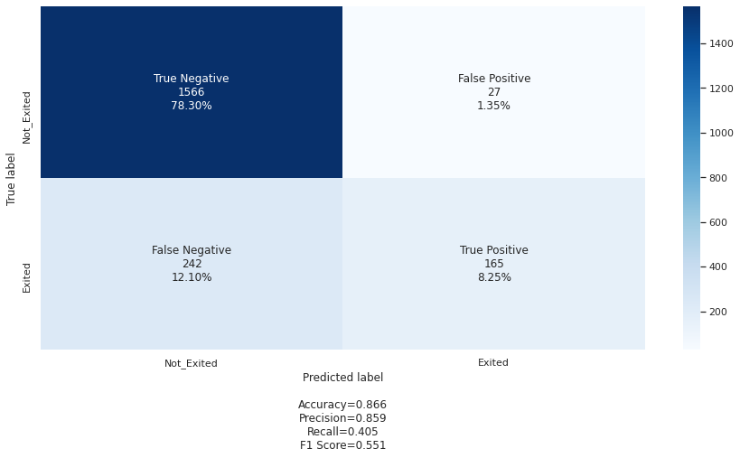

```python
#Confusion Matrix on  test set
y_pred1 = model.predict(X_test)
for i in range(len(y_test)):
    if y_pred1[i]>0.5:
        y_pred1[i]=1
    else:
        y_pred1[i]=0



cm2=confusion_matrix(y_test, y_pred1)
labels = ['True Negative','False Positive','False Negative','True Positive']
categories = [ 'Not_Exited','Exited']
make_confusion_matrix(cm2,
                      group_names=labels,
                      categories=categories,
                      cmap='Blues')
```

```python
#Storing Accuracy,Precision,Recall and F1-score for Model-1 in a dataframe for compare at the end
tn = cm2[0][0]
fp = cm2[0][1]
fn = cm2[1][0]
tp = cm2[1][1]

acc1 = (tp + tn) / (tp + tn + fp + fn)
precision1 = tp/(tp+fp)
recall1 = tp/(tp+fn)
f1 = 2*precision1*recall1/(precision1+recall1)

df = pd.DataFrame(np.array([[acc1,precision1,recall1,f1]]),columns=['Accuracy', 'Precision', 'Recall','F1-Score'],index=['Model1-def'])
df_compare = df_compare.append(df)
```

**ROC-AUC and Precision-Recall curves**

- **ROC Curves** summarize the trade-off between the true positive rate and false positive rate for a predictive model using different probability thresholds
- **Precision-Recall curves** summarize the trade-off between the true positive rate and the positive predictive value for a predictive model using different probability thresholds
- ROC curves are appropriate when the observations are balanced between each class, whereas precision-recall curves are appropriate for imbalanced datasets
- Now we are going to see both to find out the threshold values

**ROC-AUC**

- ROC curve is a plot of the false positive rate (x-axis) versus the true positive rate (y-axis) for a number of different candidate threshold values between 0.0 and 1.0
- True Positive Rate (Sensitivity) = True Positives / (True Positives + False Negatives)
- False Positive Rate (1 - Specificity) = False Positives / (False Positives + True Negatives)
- The area under the curve (AUC) can be used as a summary of the model performance
- Smaller values on the x-axis of the plot indicate lower false positives and higher true negatives
- Larger values on the y-axis of the plot indicate higher true positives and lower false negatives
- A model with no skill is represented at the point (0.5, 0.5). A model with no skill at each threshold is represented by a diagonal line from the bottom left of the plot to the top right and has an AUC of 0.5
- A model with perfect skill is represented at a point (0,1). A model with perfect skill is represented by a line that travels from the bottom left of the plot to the top left and then across the top to the top right
- roc_auc_score gives AUC score between 0 and 1, for no skill and perfect skill respectively
- The Geometric Mean or G-Mean is a metric for imbalanced classification that, if optimized, will seek a balance between the sensitivity and the specificity
- G-Mean = sqrt(Sensitivity * Specificity)

```python
#variable for storing best_threshold value
best_threshold = 0
```

```python
#Function to produce ROC-AUC curve
def fn_ROC_AUC (mdl,testX,testY):
  # probabilities from model
  model_probs = mdl.predict(testX)

  # calculate roc curves
  model_fpr, model_tpr, thresholds = roc_curve(testY, model_probs)

  # calculate the g-mean for each threshold
  gmeans = np.sqrt(model_tpr * (1-model_fpr))

  # locate the index of the largest g-mean
  ix = np.argmax(gmeans)

  print('Best Threshold=%f, G-Mean=%.3f' % (thresholds[ix], gmeans[ix]))

  #save best threshold for confusion matrix
  global best_threshold
  best_threshold = thresholds[ix]

  # calculate auc scores
  ns_auc = roc_auc_score(testY, np.zeros([2000,1]))
  model_auc = roc_auc_score(testY, model_probs)

  # summarize scores
  print('No Skill: ROC AUC=%.3f' % (ns_auc))
  print('Model: ROC AUC=%.3f' % (model_auc))

  # plot the roc curve for the model
  plt.plot([0,1], [0,1], linestyle='--', label='No Skill')
  plt.plot(model_fpr, model_tpr, marker='.', label='Model')
  plt.scatter(model_fpr[ix], model_tpr[ix], marker='o', color='black', label='Best')

  # axis labels
  plt.xlabel('False Positive Rate (FPR)')
  plt.ylabel('True Positive Rate (TPR)')

  # show the legend
  plt.legend()

  # show the plot
  plt.show()
```

```
Best Threshold=0.269671, G-Mean=0.751
No Skill: ROC AUC=0.500
Model: ROC AUC=0.839
```

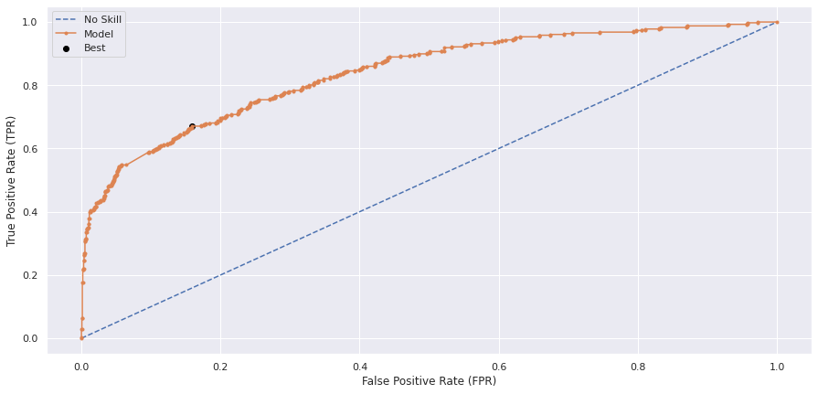

```python
#function call to show ROC curve
fn_ROC_AUC(model,X_test,y_test)
```

- Smaller values on the x-axis of the plot indicate lower false positives and higher true negatives
- Larger values on the y-axis of the plot indicate higher true positives and lower false negatives
- From the threshold above there is still scope of improvement for FN (lower) while keeping an eye on FP

**Precision-Recall curve**

- A precision-recall curve focuses on the performance of a classifier on the positive (minority class) only
- A line plot created for the thresholds in ascending order with recall on the x-axis and precision on the y-axis
- A no-skill model is represented by a horizontal line with a precision that is the ratio of positive examples in the dataset
- Perfect skill classifier has full precision and recall with a dot in the top-right corner

```python
#Function to produce Precision-Recall curve
def fn_Precision_Recall(mdl,testX,testY):
  # probabilities from model
  model_probs = mdl.predict(testX)

  # calculate roc curves
  pr, rc, thresholds = precision_recall_curve(testY, model_probs)

  # calculate f-score
  fscore = (2 * pr * rc) / (pr + rc)

  # locate the index of the largest f-score
  ix = np.argmax(fscore)

  print('Best Threshold=%f, F-Score=%.3f' % (thresholds[ix], fscore[ix]))

  #save best threshold for confusion matrix
  global best_threshold
  best_threshold = thresholds[ix]

  # plot the precision-recall curve for the model
  no_skill = len(testY[testY==1]) / len(testY)
  plt.plot([0,1], [no_skill,no_skill], linestyle='--', label='No Skill')
  plt.plot(rc, pr, marker='.', label='Model')
  plt.scatter(rc[ix], pr[ix], marker='o', color='black', label='Best')

  # axis labels
  plt.xlabel('Recall')
  plt.ylabel('Precision')

  # show the legend
  plt.legend()

  # show the plot
  plt.show()
```

```
Best Threshold=0.338440, F-Score=0.619
```

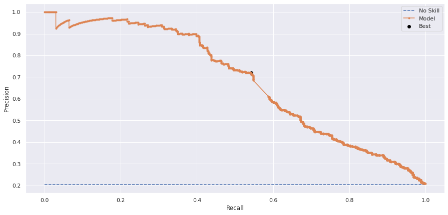

```python
#Function call to show Precision_Recall curve
fn_Precision_Recall(model,X_test,y_test)
```

**Optimal threshold**

- ROC-AUC curve gives optimal threshold as 0.26, compared to the default threshold of 0.5 to decide on if a given observation belongs to the major or minor class
- Precision-Recall curve gives optimal threshold as 0.34, compared to the default threshold of 0.5 to decide on if a given observation belongs to the major or minor class

**Confusion Matrix using optimal threshold from Precision-Recall curve**

- We have found the optimal threshold using both ROC-AUC curve and Precision-Recall curve.
- When the input dataset is imbalanced (like this problem statement), Precision-Recall curve is more appropriate to find optimal threshold.
- Lets see the confusion matrix using this optimal threshold from Precision-Recall curve

```python
#print optimal threshold from precision-recall curve
print('Opimal Threshold = %f' % (best_threshold))
```

```
Opimal Threshold = 0.338440
```

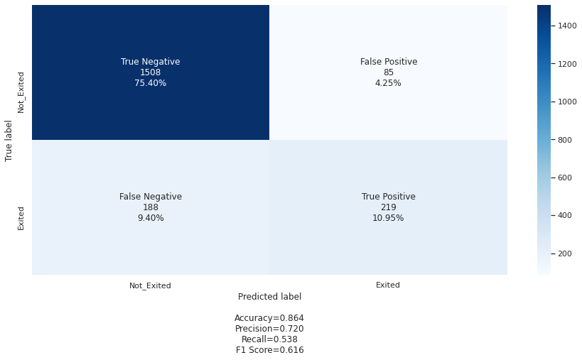

```python
#Confusion Matrix on  test set
y_pred1 = model.predict(X_test)
for i in range(len(y_test)):
    if y_pred1[i] > round(best_threshold,2):
        y_pred1[i] = 1
    else:
        y_pred1[i]=0



cm2=confusion_matrix(y_test, y_pred1)
labels = ['True Negative','False Positive','False Negative','True Positive']
categories = [ 'Not_Exited','Exited']
make_confusion_matrix(cm2,
                      group_names=labels,
                      categories=categories,
                      cmap='Blues')
```

- We can see that, with the new threshold, Recall has improved
- False negative has come down

```python
#Storing Accuracy,Precision,Recall and F1-score for Model-1 in a dataframe for compare at the end
tn = cm2[0][0]
fp = cm2[0][1]
fn = cm2[1][0]
tp = cm2[1][1]

acc1 = (tp + tn) / (tp + tn + fp + fn)
precision1 = tp/(tp+fp)
recall1 = tp/(tp+fn)
f1 = 2*precision1*recall1/(precision1+recall1)


df = pd.DataFrame(np.array([[acc1,precision1,recall1,f1]]),columns=['Accuracy', 'Precision', 'Recall','F1-Score'],index=['Model1-opt'])
df_compare = df_compare.append(df)
```

**Model-1 performance - Can model performance be improved?**

**Model-2**

- Hyperparameter tuning - Early stopping, Weight Initialization

```python
#adding earlystopping callback
es= keras.callbacks.EarlyStopping(monitor='val_loss',
                              min_delta=0,
                              patience=15,
                             verbose=0, mode='min', restore_best_weights= True)
#initialize the model
Model2 = Sequential()

#Initializing the weights uisng he_normal
n_inputs=X_train.shape[1]

Model2.add(Dense(65, input_shape=(n_inputs, ), kernel_initializer='he_normal', activation='relu'))
Model2.add(Dropout(0.5))
Model2.add(Dense(65, kernel_initializer='he_normal', activation='relu'))
Model2.add(Dropout(0.5))
Model2.add(Dense(1, kernel_initializer='he_normal', activation='sigmoid'))

Model2.compile(Adam(lr=0.001), loss='binary_crossentropy', metrics=['accuracy'])
```

```python
Model2.summary()
```

```
Model: "sequential_1"
_________________________________________________________________
Layer (type)                 Output Shape              Param #
=================================================================
dense_4 (Dense)              (None, 65)                780
_________________________________________________________________
dropout_1 (Dropout)          (None, 65)                0
_________________________________________________________________
dense_5 (Dense)              (None, 65)                4290
_________________________________________________________________
dropout_2 (Dropout)          (None, 65)                0
_________________________________________________________________
dense_6 (Dense)              (None, 1)                 66
=================================================================
Total params: 5,136
Trainable params: 5,136
Non-trainable params: 0
_________________________________________________________________
```

```python
his_mod2= Model2.fit(X_train, y_train, validation_split=0.2, batch_size=50, epochs=40, callbacks=[es], shuffle=True, verbose=1)
```

- Plotting the train and validation loss

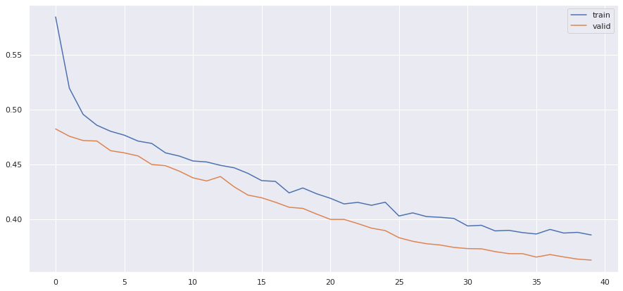

```python
# Capturing learning history per epoch
hist  = pd.DataFrame(his_mod2.history)
hist['epoch'] = his_mod2.epoch

# Plotting accuracy at different epochs
plt.plot(hist['loss'])
plt.plot(hist['val_loss'])
plt.legend(("train" , "valid") , loc =0);
```

- Both training and validation loss show continuous decrease, but with fluctuation